# Cluster Analysis

2026-09-10

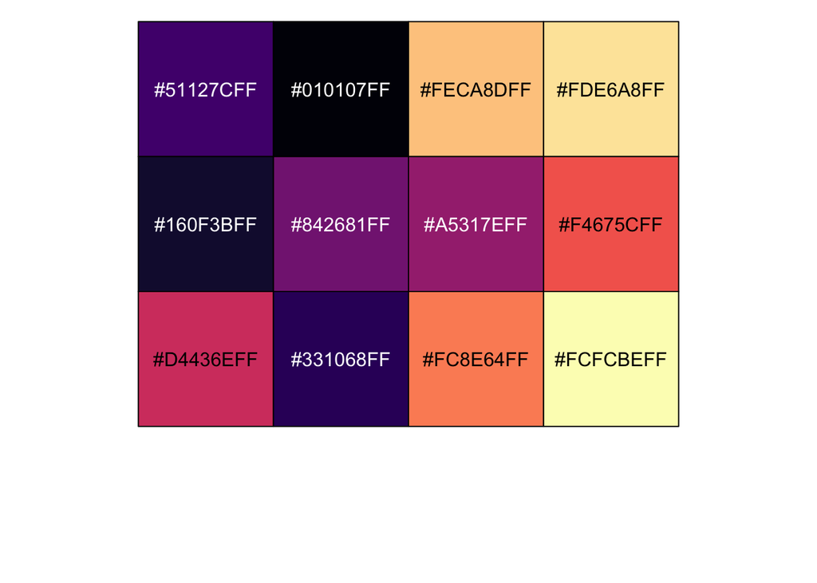

```r
labelVectorRedo <- setNames(c(1, 2, 3, 4, 5, 6, 7, 8, 9, 10, 11, "unClustered"), c("1", "2", "3", "4", "5", "6", "7", "8", "9", "10", "11", "BTC"))

Viridiff <- viridis(555, option = "A")
set.seed(94)
PrimerColors <- sprintf("%s", sample(Viridiff, 6))
set.seed(91)
DysbioColors <- sprintf("%s", sample(Viridiff, 12))
DysbioColors <- setNames(DysbioColors, labelVectorRedo)
set.seed(99)
StudyColors <- sprintf("%s", sample(Viridiff, 14))
set.seed(94)
HealthColors <- sprintf("%s", sample(Viridiff, 7))

show_col(DysbioColors)
```

load in Cluster Metadata

```r
myMeta <- read_tsv('~/Desktop/Lozupone_022425/Keith/Metaanalysis/metaManuscript/UpdatedData082826/metaMappingEW_KZHFiltered4.tsv')
myMeta <- as_tibble(myMeta)
colnames(myMeta)[1]<-"SampleID"

fullerunWeightUniFullPcoa <- read_tsv('~/Desktop/Lozupone_022425/Keith/Metaanalysis/metaManuscript/UpdatedData082826/unweightedPC1234withMeta.tsv')

unWeightUniPcoaRedefDysbio11 <- read_tsv("~/Desktop/Lozupone_022425/Keith/Metaanalysis/metaManuscript/UpdatedData082826/unWeighted3999DysFMTClusters_082926.tsv")

# left joined myMeta to DysbioClusters to create FullFMTClusterMeta
FullFMTClusterMeta<- read_tsv("~/Desktop/Lozupone_022425/Keith/Metaanalysis/metaManuscript/UpdatedData082826/ReClusters3999Dysbio_metaAnalysis_082926.tsv")
FullFMTClusterMeta$unNeighborClusters<- factor(
FullFMTClusterMeta$unNeighborClusters, levels = c(labelVectorRedo))

#this is just clustering meta-data
DysbioClusters<- read_tsv("~/Desktop/Lozupone_022425/Keith/Metaanalysis/metaManuscript/UpdatedData082826/11w5DysbioClusters_082926.tsv")
DysbioClusters$unNeighborClusters<- factor(
DysbioClusters$unNeighborClusters, levels = c(labelVectorRedo))

DysbioClusters %>%
  left_join(fullerunWeightUniFullPcoa)->onlyRedef11DysbioMeta

# load alpha diversity metrics
myShannon <- read_qza('~/Desktop/Lozupone_022425/Keith/Metaanalysis/metaManuscript/UpdatedData082826/core-metrics-OriginalMeta2-caseyFiltered-rared-1004/shannon_vector.qza')$data
myEvenness <- read_qza('~/Desktop/Lozupone_022425/Keith/Metaanalysis/metaManuscript/UpdatedData082826/core-metrics-OriginalMeta2-caseyFiltered-rared-1004/evenness_vector.qza')$data
myFaith <- read_qza('~/Desktop/Lozupone_022425/Keith/Metaanalysis/metaManuscript/UpdatedData082826/core-metrics-OriginalMeta2-caseyFiltered-rared-1004/faith_pd_vector.qza')$data

# turn them into tibbles and create a new column because
# tibbles don't have rownames!
myShannon <- as.tibble(rownames_to_column(myShannon, var = "SampleID"))
myEvenness<-as.tibble(rownames_to_column(myEvenness, var = "SampleID"))
myFaith %>%
 rename(
   "SampleID" = V1,
    "FaithPD" = V2 ) %>%
  as_tibble()->myFaith
```

#1.)Phylogenetic Visualization ## Will create contribution tables and Taxa Bar plots #phyloseq drains computer, feed trash beforehand

```r
qza_to_phyloseq(features ='~/Desktop/Lozupone_022425/Keith/Metaanalysis/metaManuscript/UpdatedData082826/core-metrics-OriginalMeta2-caseyFiltered-rared-1004/rarefied_table.qza',
                taxonomy ='~/Desktop/Lozupone_022425/Keith/Metaanalysis/Keiths Original Files/taxonomy_silva.qza',
                metadata = '~/Desktop/Lozupone_022425/Keith/Metaanalysis/metaManuscript/UpdatedData082826/ReClusters3999Dysbio_metaAnalysis_082926.tsv') -> phyloMetaSeq
```

Use prep_mdf to agglomerate and normalize the phyloseq object, and melt to a data frame. Here we specify that NA values should be removed with the remove_na parameter, which can be adjusted according to the needs of your visualization and analysis.

```r
prep_mdf(phyloMetaSeq) -> MetaSeqDF
write_tsv(MetaSeqDF,"~/Desktop/Lozupone_022425/Keith/Metaanalysis/metaManuscript/UpdatedData082826/AllBiomMetaSeqDF_090926", quote = "none")
```

Create abundance dataframe & color mapping dataframe Use create_color_dfs to generate a color object for the specified data. Then extract the objects used to plot. mdf represents the #object to plot; cdf represents the coloring. when using code from github, the selected groups didn’t exist because Keith and I used a SILVA classifier in this study To check Phylums present and how many instances of those Phylums

```r
MetaSeqDF %>%
dplyr::count(Phylum) %>%
  arrange(desc(n))->phylumInfo
head(phylumInfo, 5)
```

```
##            Phylum      n
## 1      Firmicutes 104006
## 2   Bacteroidetes  15768
## 3  Proteobacteria  11285
## 4  Actinobacteria   8804
## 5 Verrucomicrobia   1590
```

```r
MetaSeqDF %>%
create_color_dfs(selected_groups = c('Proteobacteria', 'Actinobacteria', 'Bacteroidetes', 'Firmicutes','Verrucomicrobia'),
                                  cvd = TRUE) -> colorObjs_Meta_Verruc

# Extract
#dataframe of metadata attached to microshades taxonomic IDs
mdf_Meta_Verruc <- colorObjs_Meta_Verruc$mdf
#write.csv(mdf_Meta, "~/Lozupone/Thesis/Meta-SS/WeightClusterMeta_mfd.csv", quote =FALSE, row.names = FALSE)

#dataframe of microshades taxonomic IDs attached to hexcodes
cdf_Meta_Verruc <- colorObjs_Meta_Verruc$cdf
#Use mdf_GP as the object to plot and use cdf_GP to assign the correct color assignments.

rm(phyloMetaSeq)
```

this is taken directly from https://karstenslab.github.io/microshades/articles/remove_na_option.html

```r
# Order the samples by Proteobacteria abundance for visual organization
reorder_samples_by(mdf_Meta_Verruc, cdf_Meta_Verruc,
                      order = "Proteobacteria",
                      group_level = "Phylum",
                      subgroup_level = "Genus",
                      sink_abundant_groups = TRUE) -> reordered_Meta_Verruc


# Extract dataframes of reorders
cdf_reordered_Meta <- reordered_Meta_Verruc$cdf
mdf_reordered_Meta <- reordered_Meta_Verruc$mdf

#preFMT

mdf_reordered_Meta %>%
  subset(unNeighborClusters %in% c("1","2","3","4","5",
                                       "6", "7", "8","9",
                                       "10", "11","unClustered")) -> mdf_11UnNeighborClustersDysbio_Meta

mdf_11UnNeighborClustersDysbio_Meta %>%
   pull(SimpleID, name = Sample)->labelDys
```

Ext Firms and Proteos Dysbio11

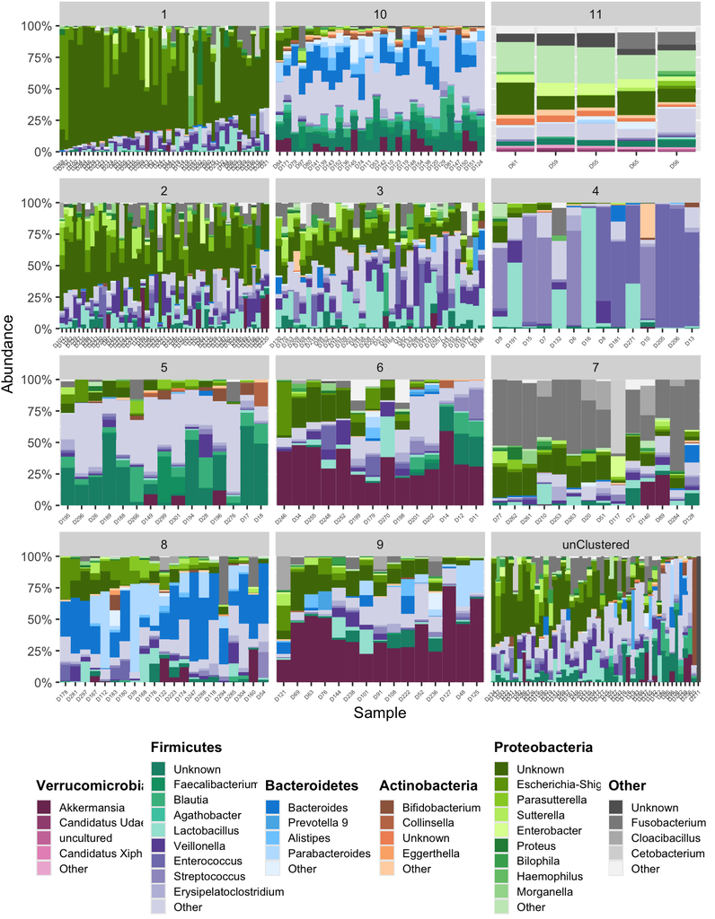

```r
#Here, we plot with extended Firmicutes colors in the mdf_11newClustersDysbio_Meta
new_groups1_redoDys11 <- extend_group(mdf_11UnNeighborClustersDysbio_Meta, cdf_Meta_Verruc, "Phylum", "Genus", "Firmicutes", existing_palette = "micro_cvd_turquoise", new_palette = "micro_purple", n_add = 5)
new_groups2_redoDys11 <- extend_group(new_groups1_redoDys11$mdf, new_groups1_redoDys11$cdf, "Phylum", "Genus", "Proteobacteria", existing_palette = "micro_cvd_green", new_palette = "micro_green", n_add = 5)

Dysbio11Colors<-as.tibble(new_groups2_redoDys11$cdf)
write_tsv(Dysbio11Colors, "~/Desktop/Lozupone_022425/Keith/Metaanalysis/metaManuscript/UpdatedData082826/colorMatchDysbio11Neighbor_090126.tsv", quote = "none")

legend_new_redoDys11 <- custom_legend(new_groups2_redoDys11$mdf, new_groups2_redoDys11$cdf)
new_legend_horiz_redoDys11 <- custom_legend(new_groups2_redoDys11$mdf, new_groups2_redoDys11$cdf, legend_key_size = 0.75, legend_text_size = 10, legend_orientation = "horizontal")
new_center_legend_horiz_redoDys11 <- plot_grid(NULL, new_legend_horiz_redoDys11, nrow=1, rel_widths=c(0.04, 0.96))

plot_microshades(new_groups2_redoDys11$mdf, new_groups2_redoDys11$cdf) +
  scale_x_discrete(labels = labelDys)+
  scale_y_continuous(labels = scales::percent, expand = expansion(0)) +
  theme(legend.position = "none")  +
  theme(axis.text.x = element_text(size= 4)) +
  facet_wrap(~unNeighborClusters, scales = "free_x", nrow = 4) +
  theme(plot.margin = margin(1,10,10,1))+
  theme(panel.spacing = unit(0.3, "lines")) ->diff_DysbioRe11

plot_grid(diff_DysbioRe11, new_center_legend_horiz_redoDys11 , nrow=2, rel_widths = c(1,1), rel_heights = c(1,0.25)) ->DysbioRe11Diff
DysbioRe11Diff
```

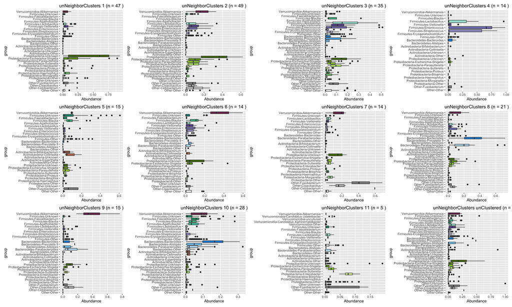

```r
plot_contributions(new_groups2_redoDys11$mdf, new_groups2_redoDys11$cdf, "unNeighborClusters", "1") -> DysbioRe11Contributions1
plot_contributions(new_groups2_redoDys11$mdf, new_groups2_redoDys11$cdf, "unNeighborClusters", "2") -> DysbioRe11Contributions2
plot_contributions(new_groups2_redoDys11$mdf, new_groups2_redoDys11$cdf, "unNeighborClusters", "3") -> DysbioRe11Contributions3
plot_contributions(new_groups2_redoDys11$mdf, new_groups2_redoDys11$cdf, "unNeighborClusters", "4") -> DysbioRe11Contributions4
plot_contributions(new_groups2_redoDys11$mdf, new_groups2_redoDys11$cdf, "unNeighborClusters", "5") -> DysbioRe11Contributions5
plot_contributions(new_groups2_redoDys11$mdf, new_groups2_redoDys11$cdf, "unNeighborClusters", "6") -> DysbioRe11Contributions6
plot_contributions(new_groups2_redoDys11$mdf, new_groups2_redoDys11$cdf, "unNeighborClusters", "7") -> DysbioRe11Contributions7
plot_contributions(new_groups2_redoDys11$mdf, new_groups2_redoDys11$cdf, "unNeighborClusters", "8") -> DysbioRe11Contributions8
plot_contributions(new_groups2_redoDys11$mdf, new_groups2_redoDys11$cdf, "unNeighborClusters", "9") -> DysbioRe11Contributions9
plot_contributions(new_groups2_redoDys11$mdf, new_groups2_redoDys11$cdf, "unNeighborClusters", "10") -> DysbioRe11Contributions10
plot_contributions(new_groups2_redoDys11$mdf, new_groups2_redoDys11$cdf, "unNeighborClusters", "11") -> DysbioRe11Contributions11
plot_contributions(new_groups2_redoDys11$mdf, new_groups2_redoDys11$cdf, "unNeighborClusters", "unClustered") -> DysbioRe11ContributionsUnClus

DysbioRe11Contributions1$box +
DysbioRe11Contributions2$box +
DysbioRe11Contributions3$box +
DysbioRe11Contributions4$box +
DysbioRe11Contributions5$box +
DysbioRe11Contributions6$box +
DysbioRe11Contributions7$box +
DysbioRe11Contributions8$box +
DysbioRe11Contributions9$box +
DysbioRe11Contributions10$box +
DysbioRe11Contributions11$box +
DysbioRe11ContributionsUnClus$box->conts11ReDysbio
conts11ReDysbio
```

Summarizing alpha-diversity metrics

```r
Dysbio11Colors<-read_tsv("~/Desktop/Lozupone_022425/Keith/Metaanalysis/metaManuscript/UpdatedData082826/colorMatchDysbio11Neighbor_090126.tsv")

FullFMTClusterMeta %>%
  left_join(myShannon) %>%
  left_join(myEvenness) %>%
  left_join(myFaith) -> myFMTClusterMetaAlphas


# Tidying
myFMTClusterMetaAlphas %>%
  select(SampleID, unNeighborClusters, SimpleID,
         shannon_entropy, FaithPD, pielou_evenness) ->lessAlphas

lessAlphas %>% gather(-SampleID,-unNeighborClusters, -SimpleID,
         key = 'Alpha', value = 'Value') -> tidyAlphas

lessAlphas %>%
    filter(unNeighborClusters  != 'NA' ) %>%
    group_by(unNeighborClusters) %>%
    summarise(medianFaith = median(FaithPD), meanFaith = mean(FaithPD),
              minFaith = min(FaithPD), maxFaith = max(FaithPD),
              IQRFaith = IQR(FaithPD), sdFaith = sd(FaithPD),
              medianEven = median(pielou_evenness),meanEven = mean(pielou_evenness),
              minEven = min(pielou_evenness), maxEven = max(pielou_evenness),
              IQREven = IQR(pielou_evenness), sdEven = sd(pielou_evenness),
              medianShan = median(shannon_entropy),meanShan = mean(shannon_entropy),
              minShan = min(shannon_entropy), maxShan = max(shannon_entropy),
              IQRShan = IQR(shannon_entropy), sdShan = sd(shannon_entropy))-> Dys11AlphaAvgs
print(Dys11AlphaAvgs)
```

```
## # A tibble: 12 × 19
##    unNeighborClusters medianFaith meanFaith minFaith maxFaith IQRFaith sdFaith
##    <fct>                    <dbl>     <dbl>    <dbl>    <dbl>    <dbl>   <dbl>
##  1 1                         8.52      9.03     3.89     16.9     4.31    3.10
##  2 2                        10.7      11.3      5.87     17.0     3.77    2.83
##  3 3                        13.6      14.7      7.96     35.3     4.33    5.37
##  4 4                         8.57      9.85     3.98     19.2     6.54    4.37
##  5 5                        17.6      18.6     11.2      30.5     6.74    5.24
##  6 6                        16.2      15.4      6.80     24.8     9.88    5.84
##  7 7                        13.7      13.9      7.58     21.7     6.86    4.42
##  8 8                        14.9      16.4      5.92     33.5     7.32    6.64
##  9 9                        14.1      14.8     10.5      25.2     5.66    4.16
## 10 10                       30.2      31.8     23.4      47.4     9.46    6.63
## 11 11                      109.      107.      91.1     120.     25.1    13.6
## 12 unClustered              14.0      15.1      7.74     30.2     5.87    6.02
## # ℹ 12 more variables: medianEven <dbl>, meanEven <dbl>, minEven <dbl>,
## #   maxEven <dbl>, IQREven <dbl>, sdEven <dbl>, medianShan <dbl>,
## #   meanShan <dbl>, minShan <dbl>, maxShan <dbl>, IQRShan <dbl>, sdShan <dbl>
```

```r
write_tsv(Dys11AlphaAvgs, "~/Desktop/Lozupone_022425/Keith/Metaanalysis/metaManuscript/UpdatedData082826/Dysbio11AlphaSumTable_090926.tsv", quote = "none")
```

Looking into High Cluster 11 Faith PD

```r
MetaSeqDF %>%
  filter(day_relative_to_fmt2 != "missing") %>%
  rename("SampleID" = Sample)-> MetaSeqDF2
MetaSeqDF2$day_relative_to_fmt2 <- as.numeric(MetaSeqDF2$day_relative_to_fmt2)
MetaSeqDF2 %>%
  unite("study_hostID", experiment_title, host_subject_id, sep = "_", remove = FALSE) %>%
  group_by(study_hostID) %>%
  fill(SimpleID, .direction = "downup") %>%
   pull(SimpleID, name = study_hostID)->SimpleLabels

Phyla_colors <- setNames(Dysbio11Colors$hex, Dysbio11Colors$Top_Phylum)

pdf("~/Desktop/Lozupone_022425/Keith/Metaanalysis/metaManuscript/UpdatedData082826/Cluster11PhylaRichness2.pdf", width = 20, height = 12)
MetaSeqDF %>%
  filter(unNeighborClusters != "NA") %>%
  group_by(unNeighborClusters, Phylum, Genus) %>%
  summarise(diversity = n_distinct(OTU)) %>%
  filter(diversity > 5 ) %>%
  ggplot(aes(y= diversity, x= unNeighborClusters, fill = Phylum)) +
  theme_bw(base_size = 18) +
      labs(y = "Distinct OTUs (Phyla contain >5)",
       tag = "b") +
  ggtitle("Phyla Richness (>5 distinct OTUs) in Dysbiotic Clusters") +
    scale_x_discrete(limits=c("1","2","3","4","5","6","7","8","9","10","11","unClustered"))+
  geom_col()+
  geom_label(aes(label =Phylum), size = 3, alpha = 0.7,  position = position_stack(vjust = 0.5))+
      scale_fill_manual(values = Phyla_colors)+
      theme(axis.text.x = element_text(angle = 300, hjust = 0),
        axis.title.x = element_blank(),
        legend.position="none",
        legend.text = element_text(size = 10),
        legend.title = element_text(size = 12),
        legend.margin = margin(t = 0, b = 0, r = 0, l = 0))->FigS8b
FigS8b

MetaSeqDF %>%
  filter(unNeighborClusters != "NA") %>%
  group_by(unNeighborClusters, Phylum, Genus, host_subject_id) %>%
  summarise(diversity = n_distinct(OTU)) ->HostDistinctGeneraRichness
write_tsv(HostDistinctGeneraRichness, "~/Desktop/Lozupone_022425/Keith/Metaanalysis/metaManuscript/UpdatedData082826/HostDistinctGeneraRichness_090926.tsv",  quote = "none")

MetaSeqDF %>%
  filter(unNeighborClusters != "NA") %>%
  group_by(unNeighborClusters, Phylum, Genus) %>%
  summarise(diversity = n_distinct(OTU)) %>%
  filter(diversity > 4 ) %>%
  ggplot(aes(y= diversity, x= unNeighborClusters, fill = Phylum)) +
  theme_bw(base_size = 18) +
      labs(y = "Distinct OTUs (Phyla contain >4)",
       tag = "b") +
  ggtitle("Phyla Richness (>4 distinct OTUs) in Dysbiotic Clusters") +
  scale_x_discrete(limits=c("1","2","3","4","5","6","7","8","9","10","11","unClustered"))+
  geom_col()+
  geom_label(aes(label =Phylum), size = 3, alpha = 0.7,  position = position_stack(vjust = 0.5))+
      scale_fill_manual(values = Phyla_colors)+
      theme(axis.text.x = element_text(angle = 300, hjust = 0),
        axis.title.x = element_blank(),
        legend.position="none",
        legend.text = element_text(size = 10),
        legend.title = element_text(size = 12),
        legend.margin = margin(t = 0, b = 0, r = 0, l = 0))->FigS8balt4
FigS8balt4

MetaSeqDF2 %>%
  unite("study_hostID", experiment_title, host_subject_id, sep = "_", remove = FALSE) %>%
  group_by(study_hostID) %>%
  fill(unNeighborClusters, .direction = "downup") %>%
  ungroup() %>%
  filter(unNeighborClusters == "11") %>%
  group_by(study_hostID, day_relative_to_fmt2, Phylum, Genus) %>%
  summarise(diversity = n_distinct(OTU)) %>%
  filter(day_relative_to_fmt2 < 89) %>%
  #filter(diversity > 2) %>%
  ggplot(aes(y= diversity, x= day_relative_to_fmt2, fill = Phylum)) +
  theme_bw(base_size = 18) +
    labs(y = "Distinct OTUs",
       tag = "c") +
  ggtitle("Phyla Richness after FMT in Cluster 11") +
  geom_col()+
    facet_grid(row = vars(study_hostID), labeller= as_labeller(SimpleLabels))+
      scale_fill_manual(values = Phyla_colors)+
      theme(axis.text.x = element_text(angle = 300, hjust = 0),
        axis.title.x = element_blank(),
        legend.position="bottom",
        legend.text = element_text(size = 10),
        legend.title = element_text(size = 12),
        legend.margin = margin(t = 0, b = 0, r = 0, l = 0))->FigS8c
FigS8c
dev.off()
```

```r
pdf("~/Desktop/Lozupone_022425/Keith/Metaanalysis/metaManuscript/UpdatedData082826/Cluster11PhylaPostAlt2.pdf", width = 11, height = 8.5)
MetaSeqDF2 %>%
  unite("study_hostID", experiment_title, host_subject_id, sep = "_", remove = FALSE) %>%
  group_by(study_hostID) %>%
  fill(unNeighborClusters, .direction = "downup") %>%
  ungroup() %>%
  filter(unNeighborClusters == "11") %>%
  group_by(study_hostID, day_relative_to_fmt2, Phylum, Genus) %>%
  summarise(diversity = n_distinct(OTU)) %>%
  filter(day_relative_to_fmt2 < 89) %>%
  #filter(diversity > 2) %>%
  ggplot(aes(y= diversity, x= day_relative_to_fmt2, fill = Phylum)) +
  theme_bw(base_size = 18) +
    labs(y = "Distinct OTUs",
       tag = "c") +
  ggtitle("Phyla Richness after FMT in Cluster 11") +
  geom_col()+
    scale_x_break(c(10, 40), scales = 2.5,ticklabels=c(40,50,60,70,80))+
    facet_grid(row = vars(study_hostID), labeller= as_labeller(SimpleLabels))+
      scale_fill_manual(values = Phyla_colors)+
      theme(axis.text.x = element_text(angle = 300, hjust = 0),
        axis.title.x = element_blank(),
        legend.position="bottom",
        legend.text = element_text(size = 10),
        legend.title = element_text(size = 12),
        legend.margin = margin(t = 0, b = 0, r = 0, l = 0))->FigS8calt
FigS8calt
MetaSeqDF2 %>%
  unite("study_hostID", experiment_title, host_subject_id, sep = "_", remove = FALSE) %>%
  group_by(study_hostID) %>%
  fill(unNeighborClusters, .direction = "downup") %>%
  ungroup() %>%
  filter(unNeighborClusters == "11") %>%
  group_by(study_hostID, day_relative_to_fmt2, Phylum, Genus) %>%
  summarise(diversity = n_distinct(OTU)) %>%
  filter(day_relative_to_fmt2 < 89) %>%
  #filter(diversity > 2) %>%
  ggplot(aes(y= diversity, x= day_relative_to_fmt2, fill = Phylum)) +
  theme_bw(base_size = 18) +
    labs(y = "Distinct OTUs",
       tag = "c") +
  ggtitle("Phyla Richness after FMT in Cluster 11") +
  geom_col()+
    scale_x_break(c(10, 40), scales = 2.5)+
        scale_x_continuous(breaks=c(0,5, 10, 40,50, 60, 70))+
    facet_grid(row = vars(study_hostID), labeller= as_labeller(SimpleLabels))+
      scale_fill_manual(values = Phyla_colors)+
      theme(axis.text.x = element_text(angle = 300, hjust = 0),
        axis.title.x = element_blank(),
        legend.position="bottom",
        legend.text = element_text(size = 10),
        legend.title = element_text(size = 12),
        legend.margin = margin(t = 0, b = 0, r = 0, l = 0))->FigS8calt2
FigS8calt2
dev.off()
```

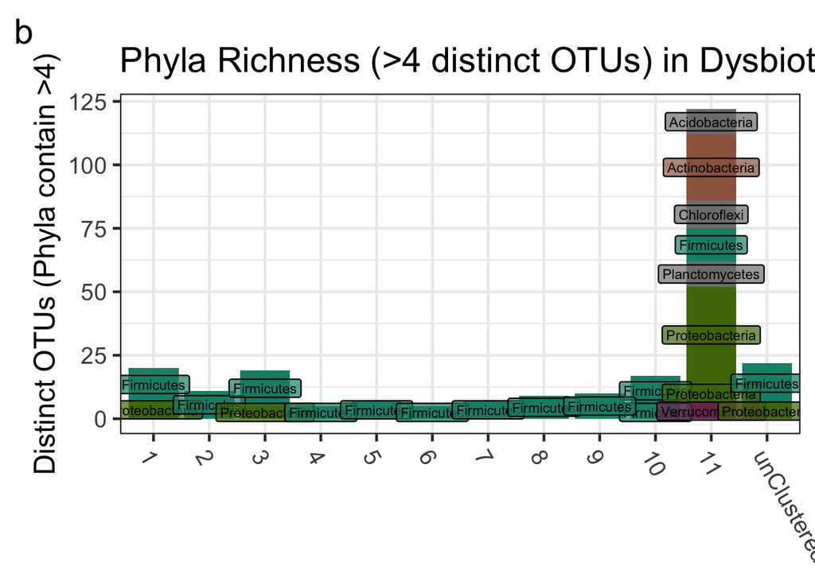

```r
FigS8balt4
```

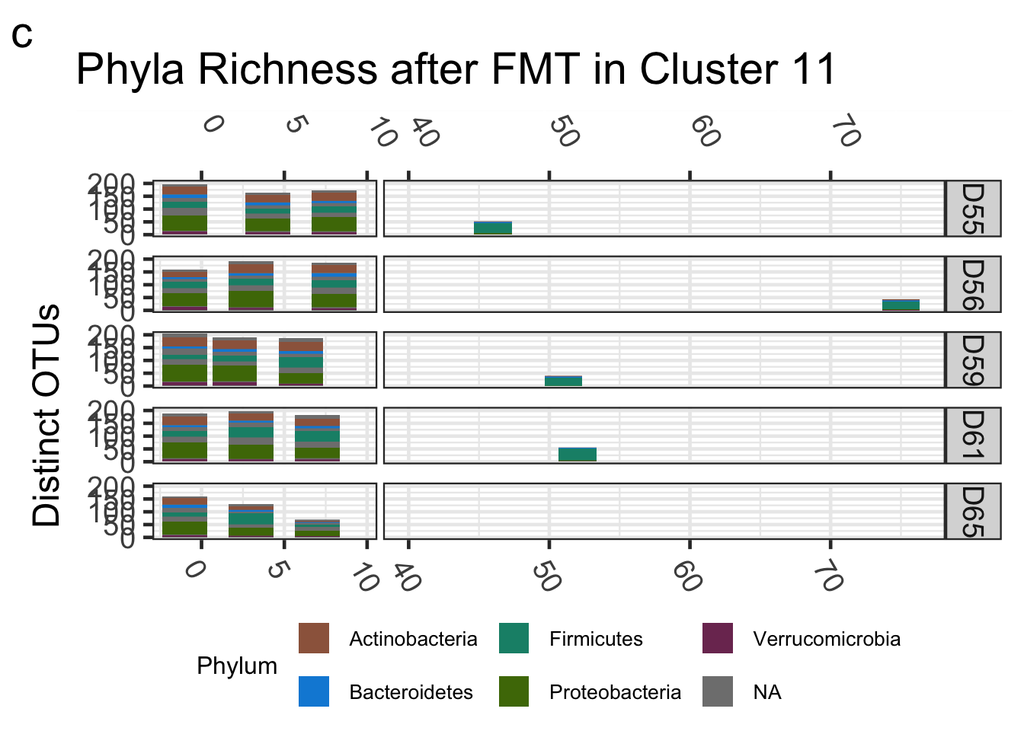

```r
FigS8calt2
```

Want to determine relative abundances of taxa that dominate clusters

```r
DysbioRe11Box <- read_tsv("~/Desktop/Lozupone_022425/Keith/Metaanalysis/metaManuscript/UpdatedData082826/DysbioNeigh11TaxaAbund_090126.tsv")
Dysbio11Colors<- read_tsv("~/Desktop/Lozupone_022425/Keith/Metaanalysis/metaManuscript/UpdatedData082826/colorMatchDysbio11Neighbor_090126.tsv")

Dysbio11Colors %>%
  select(-Top_Phylum,-Top_Genus) %>%
  right_join(DysbioRe11Box, join_by(group)) %>%
   rename(
   "SampleID" = Sample)->DysbioRe11Box

Group_colors <- setNames(Dysbio11Colors$hex, Dysbio11Colors$group)

DysbioRe11Box %>%
  select(SampleID,Abundance,unNeighborClusters ,group)->Re11AbundTable

Re11AbundTable %>%
  group_by(SampleID) %>%
  slice_max(Abundance, n = 2) %>%
  ungroup()->SampleDomMembers

Re11AbundTable %>%
  group_by(unNeighborClusters,group) %>%
  summarise(medianAbundance = median(Abundance),
         meanAbundance = mean(Abundance),
         minimumAbundance = min(Abundance),
         maximumAbundance = max(Abundance),
         IQRAbundance = IQR(Abundance),
         sdAbundance = sd(Abundance),
         nAbundance = n()) %>%
  ungroup()->ClusterTaxaGroupStats
write_tsv(ClusterTaxaGroupStats, "~/Desktop/Lozupone_022425/Keith/Metaanalysis/metaManuscript/UpdatedData082826/Dysbio11NeighborTopGroupAbund_090926.tsv", quote = "none")
```

plot those groups and show Faith PD

```r
pdf("~/Desktop/Lozupone_022425/Keith/Metaanalysis/metaManuscript/UpdatedData082826/TopTaxaByCluster_090926.pdf", width = 20, height = 12)
ClusterTaxaGroupStats %>%
  filter(nAbundance > 1) %>%
  group_by(unNeighborClusters) %>%
  slice_max(order_by = meanAbundance, n = 3) %>%
  ungroup() %>%
  left_join(Re11AbundTable, join_by(unNeighborClusters,group)) %>%
  ggplot() +
  theme_bw(base_size = 10) +
  labs(y = "Relative Abundance",
       tag = "b") +
    geom_label(data = Dys11AlphaAvgs,
             aes(fill = meanFaith , label = round(meanFaith, digits = 3)),x=2, y = 1.15, size = 3, alpha = 0.7)+
            scale_fill_gradient2(low = "blue",
                            mid = "white",
                            high = "green",
                            midpoint = 20,
                            guide = guide_colorbar(barwidth= unit(5, "cm"),
                                                    title = "Faith PD"))+
   new_scale_fill() +
  geom_boxplot(aes(y= Abundance, x= group, fill = group), alpha = 0.7,)+
  geom_point(aes( y= Abundance, x= group, fill = group), alpha = 0.5, pch = 21, size = 2.5)+
    scale_fill_manual(values = Group_colors,
                      guide = "none")+
  facet_wrap(~unNeighborClusters, scales = "free_x", nrow = 4)+
  scale_y_continuous(limits = c(0,1.15), breaks = c(0,0.2,0.4,0.6,0.8,1))+
  theme(axis.text.x = element_blank(),
        axis.title.x = element_blank())+
  theme(legend.position="bottom",
        legend.text = element_text(size = 10),
        legend.title = element_text(size = 12),
        legend.margin = margin(t = 0, b = 0, r = 0, l = 0))->ClusterTopTaxa
ClusterTopTaxa

ClusterTaxaGroupStats %>%
  filter(nAbundance > 1) %>%
  group_by(unNeighborClusters) %>%
  slice_max(order_by = meanAbundance, n = 3) %>%
  ungroup() %>%
  left_join(Re11AbundTable, join_by(unNeighborClusters,group)) %>%
  ggplot() +
  theme_bw(base_size = 10) +
  labs(y = "Relative Abundance",
       tag = "b") +
    geom_label(data = Dys11AlphaAvgs,
             aes(fill = meanFaith , label = round(meanFaith, digits = 3)),x=2, y = 1.15, size = 3, alpha = 0.7)+
            scale_fill_gradient2(low = "blue",
                            mid = "white",
                            high = "green",
                            midpoint = 20,
                            guide = guide_colorbar(barwidth= unit(5, "cm"),
                                                    title = "Faith PD"))+
   new_scale_fill() +
  geom_boxplot(aes(y= Abundance, x= group, fill = group), alpha = 0.7,)+
  geom_point(aes( y= Abundance, x= group, fill = group), alpha = 0.5, pch = 21, size = 2.5)+
    scale_fill_manual(values = Group_colors,
                      guide = "none")+
  facet_wrap(~unNeighborClusters, scales = "free_x", nrow = 4)+
  scale_y_continuous(limits = c(0,1.15), breaks = c(0,0.2,0.4,0.6,0.8,1))+
  theme(axis.text.x = element_text(angle = 300, hjust = 0),
        axis.title.x = element_blank())+
  theme(legend.position="bottom",
        legend.text = element_text(size = 10),
        legend.title = element_text(size = 12),
        legend.margin = margin(t = 0, b = 0, r = 0, l = 0))->ClusterTopTaxaNames
ClusterTopTaxaNames
dev.off()
```

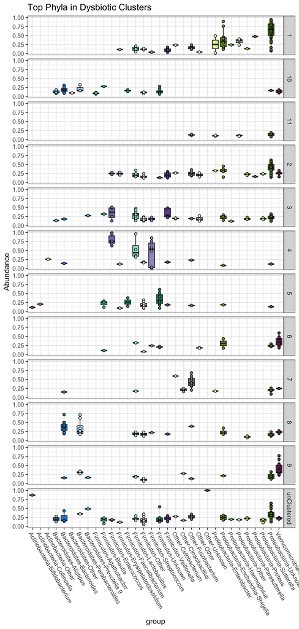

```r
SampleDomMembers %>%
  ggplot(aes(y= Abundance, x= group,fill = group)) +
  theme_bw(base_size = 18) +
  ggtitle("Top Phyla in Dysbiotic Clusters") +
  geom_boxplot()+
  geom_point( pch = 21, size = 2.5)+
  scale_fill_manual(values = Group_colors)+
  facet_grid(row = vars(unNeighborClusters), scales = "free_x")+
      theme(axis.text.x = element_text(angle = 300, hjust = 0))+
    theme(legend.position="none")
```

```r
Re11AbundTable %>%
  group_by(unNeighborClusters) %>%
  top_n(10, Abundance) %>%
  group_by(SampleID) %>%
  filter(n() == 1) %>%
  ungroup()->TopAbunRe11
```

```r
##
## Unweighted All
myUnweightUniFullPcoa <-read_qza('~/Desktop/Lozupone_022425/Keith/Metaanalysis/metaManuscript/UpdatedData082826/core-metrics-OriginalMeta2-caseyFiltered-rared-1004/unweighted_unifrac_pcoa_results.qza')$data
#get axis info
unweightUniFullProp <- myUnweightUniFullPcoa$ProportionExplained[1:4]

#unweighted full prepare axis labels
unweighted1_xaxis = paste0('PC1 (', round(unweightUniFullProp[1], 3) * 100, '%)')
unweighted2_yaxis = paste0('PC2 (', round(unweightUniFullProp[2], 3) * 100, '%)')
unweighted3_yaxis = paste0('PC3 (', round(unweightUniFullProp[3], 3) * 100, '%)')
unweighted4_yaxis = paste0('PC4 (', round(unweightUniFullProp[4], 3) * 100, '%)')

#turn them into tibbles and stuff
myUnweightUniFullPcoa <- as_tibble(myUnweightUniFullPcoa$Vectors)

colnames(myUnweightUniFullPcoa)[1] <- 'SampleID'

# reducing data if needed
myUnweightUniFullPcoa %>%
  select(SampleID,PC1, PC2,PC3, PC4) ->lessUnweightedPCoA

rm(myUnweightUniFullPcoa, unweightUniFullProp)

myMeta %>%
  left_join(lessUnweightedPCoA) %>%
  left_join(myShannon) %>%
  left_join(myFaith) %>%
  left_join(myEvenness)->fullerunWeightUniFullPcoa
write_tsv(fullerunWeightUniFullPcoa, "~/Desktop/Lozupone_022425/Keith/Metaanalysis/metaManuscript/UpdatedData082826/unweightedPC123withMeta.tsv", quote = "none")

#going to add Weighted PCoA data to each subset
myWeightUniPcoaDysbio <-read_qza('~/Desktop/Lozupone_022425/Keith/Metaanalysis/metaManuscript/UpdatedData082826/core-metrics_MetaAnalysis_preFMT-1004/weighted_unifrac_pcoa_results.qza')$data
#get axis info
WeightUniFullProp <- myWeightUniPcoaDysbio$ProportionExplained[1:3]

#unweighted full prepare axis labels
WeightDys1_xaxis = paste0('PC1 (', round(WeightUniFullProp [1], 3) * 100, '%)')
WeightDys2_yaxis = paste0('PC2 (', round(WeightUniFullProp [2], 3) * 100, '%)')
WeightDys3_xaxis = paste0('PC2 (', round(WeightUniFullProp [3], 3) * 100, '%)')

#turn them into tibbles and stuff
myWeightUniPcoaDysbio <- as_tibble(myWeightUniPcoaDysbio$Vectors)

colnames(myWeightUniPcoaDysbio)[1] <- 'SampleID'
colnames(myWeightUniPcoaDysbio)[2] <- 'PC1Dys_Wt'
colnames(myWeightUniPcoaDysbio)[3] <- 'PC2Dys_Wt'
colnames(myWeightUniPcoaDysbio)[4] <- 'PC3Dys_Wt'

# reducing data if needed
myWeightUniPcoaDysbio %>%
  select(SampleID,PC1Dys_Wt, PC2Dys_Wt, PC3Dys_Wt) ->lessWeighted123PCoADys

rm(myWeightUniPcoaDysbio, WeightUniFullProp)

fullerunWeightUniFullPcoa %>%
   left_join(lessWeighted123PCoADys) %>%
  left_join(DysbioClusters, join_by(SampleID)) ->metaUnWtUniFullSubWtPcoa
```

Plot mapping simple clustering info onto PCoA

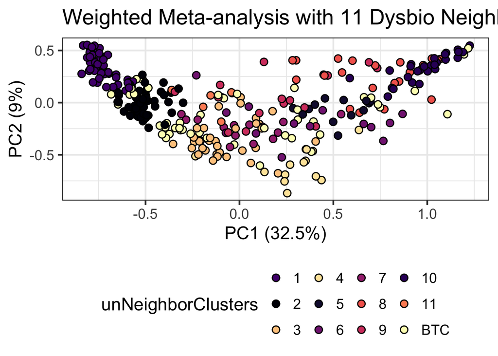

```r
#Dysbio Weight
metaUnWtUniFullSubWtPcoa %>%
   ggplot(aes(PC1Dys_Wt,PC2Dys_Wt)) +
    theme_bw(base_size = 18) +
    xlab(WeightDys1_xaxis) +
    ylab(WeightDys2_yaxis) +
  ggtitle("Weighted Meta-analysis with 11 Dysbio Neighbor Refined Enterotypes") +
    geom_point(data = metaUnWtUniFullSubWtPcoa %>%
               filter(unNeighborClusters != "NA"),
               aes(fill = unNeighborClusters), pch = 21, size = 3, color = 'black') +
        discrete_scale(aesthetics = "fill",
               palette = function(x) c(DysbioColors),
                labels = c("1","2","3","4","5","6","7","8","9","10","11", "BTC"))+
          theme(legend.position="bottom") ->DysbioWt11

print(DysbioWt11)
```

Unweighted plots

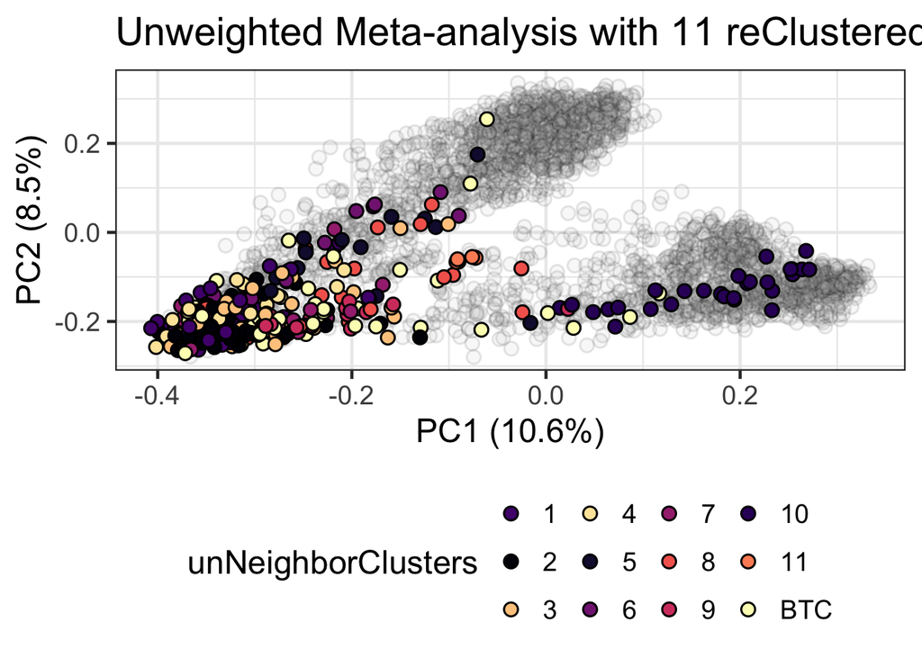

```r
##Dysbio

#11
metaUnWtUniFullSubWtPcoa%>%
  ggplot(aes(PC1,PC2)) +
    theme_bw(base_size = 18) +
    xlab(unweighted1_xaxis) +
    ylab(unweighted2_yaxis) +
  ggtitle("Unweighted Meta-analysis with 11 reClustered + Neighbors Dysbiotic Enterotypes") +
    geom_point(data = metaUnWtUniFullSubWtPcoa, fill = "grey", alpha = 0.1, pch = 21, size = 3, color = 'black') +
  geom_point(data = metaUnWtUniFullSubWtPcoa%>%
               filter(unNeighborClusters != "NA"),
               aes(fill = unNeighborClusters), pch = 21, size = 3, color = 'black') +
        discrete_scale(aesthetics = "fill",
               palette = function(x) c(DysbioColors),
                labels = c("1","2","3","4","5","6","7","8","9","10","11","BTC"))+
  theme(legend.position="bottom") -> dysbioRedo11

print(dysbioRedo11)
```

#Connect Dysbiosis Distance to Clusters and perform boxplot with stats ##Determine where extreme DDs are ##Make centroids

```r
dysbioDist <- read_tsv('~/Desktop/Lozupone_022425/Keith/Metaanalysis/metaManuscript/UpdatedData082826/MetaSampleDysbioDistances_083126.tsv')

#Attaching dysbio distances onto lotsa meta data
metaUnWtUniFullSubWtPcoa%>%
  left_join(dysbioDist)->metaUnWtUniFullSubWtPcoaDD

pdf("~/Desktop/Lozupone_022425/Keith/Metaanalysis/metaManuscript/UpdatedData082826/DysDistExtremesPcoa_090926.pdf", width = 8, height = 5)
metaUnWtUniFullSubWtPcoaDD%>%
  ggplot(aes(PC1,PC2)) +
    theme_bw(base_size = 18) +
    xlab(unweighted1_xaxis) +
    ylab(unweighted2_yaxis) +
  ggtitle("Unweighted Meta-analysis Extreme Dysbiosis Distances") +
    geom_point(data = metaUnWtUniFullSubWtPcoaDD, fill = "grey", alpha = 0.1, pch = 21, size = 3, color = 'black') +
  geom_point(data = metaUnWtUniFullSubWtPcoaDD%>%
               filter(dysbiosis_dist == 0),
               fill= "#fcfdbf",pch = 21, size = 3, color = 'black') +
  geom_point(data = metaUnWtUniFullSubWtPcoaDD%>%
               filter(dysbiosis_dist == 1),
               fill= "#51127c",pch = 21, size = 3, color = 'black') +
            theme(legend.position = "bottom",
                legend.text = element_text(size = 10),
                legend.title = element_text(size = 12),
                axis.title.x = element_text(size = 12),
                axis.text.x = element_text(size = 10),
                axis.title.y = element_text(size = 12),
                axis.text.y = element_text(size = 10),
                legend.margin = margin(t = 0, b = 0, r = 0, l = 0))
dev.off()
```

```r
metaUnWtUniFullSubWtPcoaDD %>%
  filter(unNeighborClusters != 'NA') %>%
    group_by(unNeighborClusters) %>%
    summarise(medianDysDist = median(dysbiosis_dist), mean = mean(dysbiosis_dist),
              minimum = min(dysbiosis_dist), maximum = max(dysbiosis_dist),
              IQR = IQR(dysbiosis_dist), sd = sd(dysbiosis_dist), n = n())-> Dys11DstanceAvgs

write_tsv(Dys11DstanceAvgs, "~/Desktop/Lozupone_022425/Keith/Metaanalysis/metaManuscript/UpdatedData082826/Dysbio11DistanceSumTab_090926.tsv", quote = "none")


#dysbio 11 redo
centersUnWt<- aggregate(cbind(PC1, PC2) ~ unNeighborClusters, data=metaUnWtUniFullSubWtPcoaDD, FUN=mean)
centersWt <- aggregate(cbind(PC2Dys_Wt,PC1Dys_Wt) ~ unNeighborClusters, data=metaUnWtUniFullSubWtPcoaDD, FUN=mean)
centersWt %>%
  left_join(centersUnWt) %>%
  left_join(Dys11DstanceAvgs)->CentersAvgTabel
write_tsv(CentersAvgTabel, "~/Desktop/Lozupone_022425/Keith/Metaanalysis/metaManuscript/UpdatedData082826/11DDSumStatsTable_090926.tsv", quote = "none")


colnames(CentersAvgTabel)[2] <- 'PC2Dys_WtAv'
colnames(CentersAvgTabel)[3] <- 'PC1Dys_WtAv'
colnames(CentersAvgTabel)[4] <- 'PC1Dys_UnWtAv'
colnames(CentersAvgTabel)[5] <- 'PC2Dys_UnWtAv'

metaUnWtUniFullSubWtPcoaDD  %>%
  filter(unNeighborClusters != 'NA') %>%
  group_by(unNeighborClusters) %>%
  get_summary_stats(dysbiosis_dist, type = "median_iqr") %>%
  ungroup()-> DeltaStats
write_tsv(DeltaStats, "~/Desktop/Lozupone_022425/Keith/Metaanalysis/metaManuscript/UpdatedData082826/ClusterDeltaStats_090926.tsv", quote ="none")
```

baseline stats/plots for pre filtering Clustered preFMT samples

```
##
##  Kruskal-Wallis rank sum test
##
## data:  dysbiosis_dist by unNeighborClusters
## Kruskal-Wallis chi-squared = 143.19, df = 11, p-value < 2.2e-16
```

```
## # A tibble: 1 × 5
##   .y.                n effsize method  magnitude
## * <chr>          <int>   <dbl> <chr>   <ord>
## 1 dysbiosis_dist   305   0.451 eta2[H] large
```

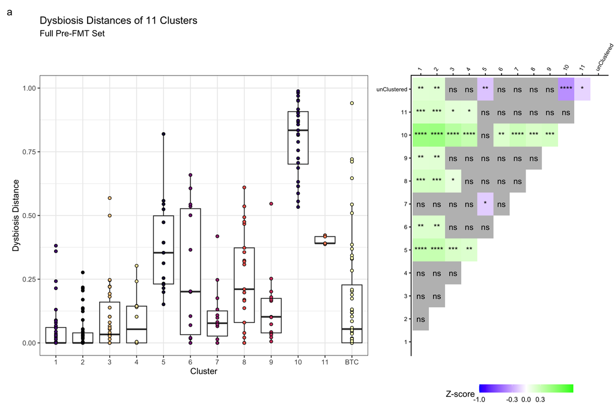

plot dysbio scores of clusters on pcoas

```r
pdf("~/Desktop/Lozupone_022425/Keith/Metaanalysis/metaManuscript/UpdatedData082826/ClusterDysDistNeighborPCoAs_090926.pdf", width = 11, height = 8.5)
#Dysbio Weight
metaUnWtUniFullSubWtPcoaDD %>%
   ggplot() +
    theme_bw(base_size = 18) +
    xlab(WeightDys1_xaxis) +
    ylab(WeightDys2_yaxis) +
      labs(tag = "c") +
       geom_point(data = CentersAvgTabel %>%
                group_by(unNeighborClusters),
                aes(y= PC2Dys_WtAv, x= PC1Dys_WtAv, fill=unNeighborClusters),
                    pch = 21, size = 15, alpha = 0.5)+
    geom_point(data = metaUnWtUniFullSubWtPcoaDD %>%
               filter(unNeighborClusters != "NA"),
               aes(y= PC2Dys_Wt, x= PC1Dys_Wt,fill = unNeighborClusters), pch = 21, size = 1.75, color = 'black') +
        discrete_scale(aesthetics = "fill",
               palette = function(x) c(DysbioColors))+
                  guides(fill = "none")+
              new_scale_fill() +
              geom_label_repel(data = CentersAvgTabel,
                                 aes(fill = medianDysDist , x = PC1Dys_WtAv, y = PC2Dys_WtAv, label = round(medianDysDist, digits = 3)),size = 3)+
        scale_fill_gradient2(low = "blue",
                            mid = "white",
                            high = "green",
                            midpoint = 0.1,
                            guide = guide_colorbar(barwidth= unit(5, "cm"),
                                                    title = "Dysbiosis Distance"))+
          theme(legend.position = "bottom",
                legend.text = element_text(size = 10),
                legend.title = element_text(size = 12),
                axis.title.x = element_text(size = 12),
                axis.text.x = element_text(size = 10),
                axis.title.y = element_text(size = 12),
                axis.text.y = element_text(size = 10),
                legend.margin = margin(t = 0, b = 0, r = 0, l = 0))->Fig1WtUni
Fig1WtUni

#Dysbio UnWeight
metaUnWtUniFullSubWtPcoaDD %>%
   ggplot() +
    theme_bw(base_size = 18) +
    xlab(unweighted1_xaxis) +
    ylab(unweighted2_yaxis) +
  labs(title = "Unweighted UniFrac PCoA with 11 Pre-FMT Clusters",
       subtitle = "Centers and Dysbiosis Scores",
       tag = "c") +
    geom_point(data = metaUnWtUniFullSubWtPcoa, aes(y= PC2, x= PC1), fill = "grey", alpha = 0.1, pch = 21, size = 3, color = 'black') +
       geom_point(data = CentersAvgTabel,
                aes(y= PC2Dys_UnWtAv, x= PC1Dys_UnWtAv, fill = unNeighborClusters),
                    pch = 21, size = 15, alpha = 0.5)+
    geom_point(data = metaUnWtUniFullSubWtPcoaDD %>%
               filter(unNeighborClusters != "NA"),
               aes(y= PC2, x= PC1,fill = unNeighborClusters ), pch = 21, size = 3, color = 'black') +
        discrete_scale(aesthetics = "fill",
               palette = function(x) c(DysbioColors))+
                guides(fill = "none")+
              new_scale_fill() +
             geom_label_repel(data = CentersAvgTabel,
                                 aes(fill = medianDysDist , x = PC1Dys_UnWtAv, y = PC2Dys_UnWtAv, label = round(medianDysDist, digits = 3)),size = 3)+
        scale_fill_gradient2(low = "blue",
                            mid = "white",
                            high = "green",
                            midpoint = 0.1,
                            guide = guide_colorbar(barwidth= unit(5, "cm"),
                                                    title = "D.D"))+
          theme(legend.position = "bottom",
                legend.text = element_text(size = 10),
                legend.title = element_text(size = 12),
                axis.title.x = element_text(size = 12),
                axis.text.x = element_text(size = 10),
                axis.title.y = element_text(size = 12),
                axis.text.y = element_text(size = 10),
                plot.title = element_text( size = 18),
                plot.subtitle = element_text( size = 16),
                legend.margin = margin(t = 0, b = 0, r = 0, l = 0))->SuppUnWtUni
SuppUnWtUni
dev.off()
```

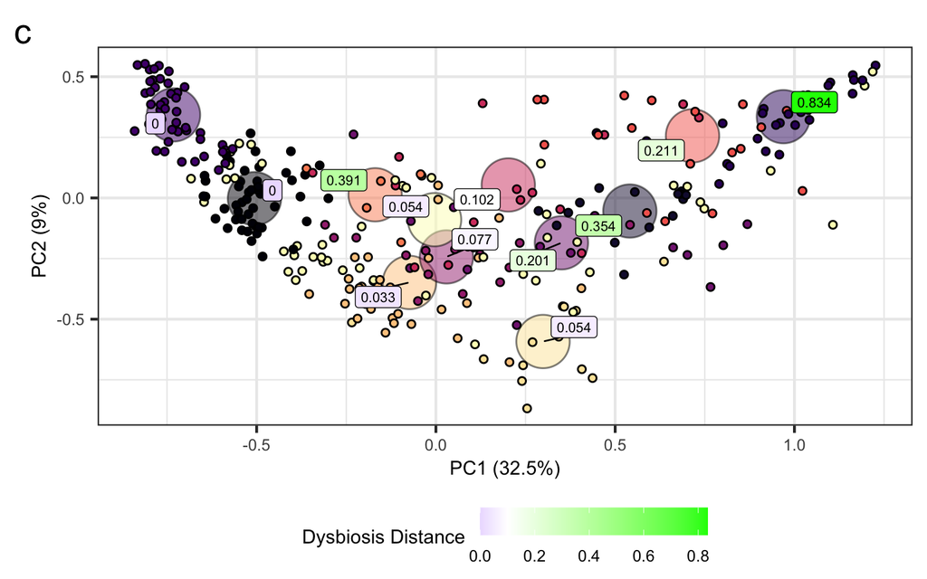

```r
Fig1WtUni
```

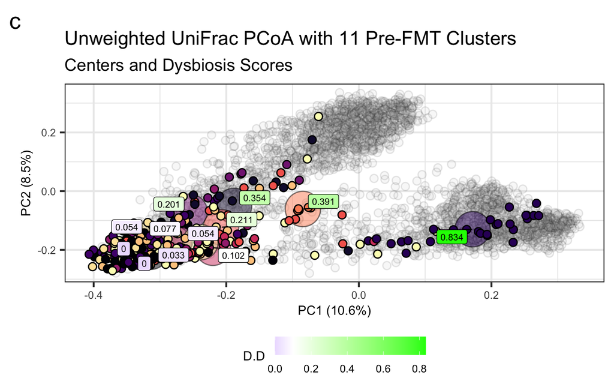

```r
SuppUnWtUni
```

```r
(free(DysbioRe11Diff) / Fig1WtUni)+
  plot_layout(nrow = 2, heights = c(1.5, 0.75))->Fig1L

(Fig1L | ClusterTopTaxa )+
  plot_layout(ncol = 2, widths = c(3,1))->Fig1

pdf("~/Desktop/Lozupone_022425/Keith/Metaanalysis/metaManuscript/UpdatedData082826/Fig5_090926.pdf", width = 8.5, height = 11)
Fig1
dev.off()
```

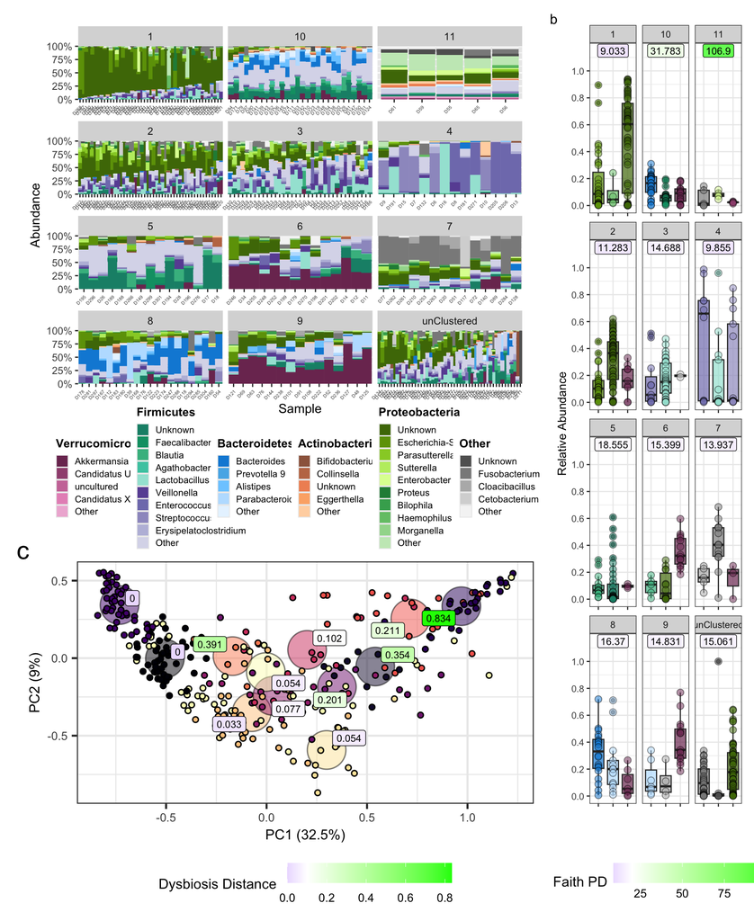

```r
Fig1
```

connect pre-postFMT. This looks at time course

```r
#One PreFMT closest to FMT and Full PostFMT samples
#filter out FMT junk and changing host_subject_id to Study host Id so that we dont group subjects that are called the same thing but are from different studies
metaUnWtUniFullSubWtPcoaDD %>%
  filter(exp_type == 'FMT') %>%
  filter(experiment_title != 'Flannigan_FMT') %>% #doesn't have a preFMT
  filter(fmt_status != 'vanco') %>%
  filter(fmt_status != 'donor') %>%
  filter(fmt_status != 'PostFMT-sham')%>%
  unite("study_hostID", experiment_title, host_subject_id, sep = "_", remove = FALSE) %>%
  group_by(study_hostID) %>%
  filter(all(c("PreFMT", "PostFMT") %in% fmt_status)) ->allPrePostFMT #patientID has both preFMT and postFMT

allPrePostFMT$day_relative_to_fmt2<-as.numeric(allPrePostFMT$day_relative_to_fmt2)

#1150 objs, some of the subject IDs have multiple values from same day. We really only want one value from preFMT. following will grab day closest to FMT
allPrePostFMT %>%
  group_by(study_hostID, fmt_status) %>%
  filter(n() > 1)%>%
  filter(fmt_status == 'PreFMT') %>%
  ungroup()-> TwoManyPre #subjects have multiple preFMT samples
nrow(TwoManyPre)
```

```
## [1] 44
```

```r
#44 have multiple pre
TwoManyPre %>%
  group_by(study_hostID) %>%
  filter(day_relative_to_fmt2 != max(day_relative_to_fmt2)) %>%
  ungroup()->EarlyExtra
nrow(EarlyExtra)
```

```
## [1] 20
```

```r
#20 early selected
#KEEP everything EXCEPT EarlyExtras
allPrePostFMT %>%
  anti_join(EarlyExtra)->PrePostAfterFMT
nrow(PrePostAfterFMT)
```

```
## [1] 1130
```

```r
#still have 2 pre samples from same patient and day
PrePostAfterFMT %>%
  group_by(study_hostID, fmt_status) %>%
  filter(n() > 1)%>%
  filter(fmt_status == 'PreFMT') %>%
  ungroup()-> TwoManyPre2
set.seed(23)
TwoManyPre2  %>%
  group_by(study_hostID) %>%
  slice_sample(n = 1) %>%
  ungroup()->doubleSample
PrePostAfterFMT %>%
  anti_join(doubleSample)->PrePostAfterFMT
nrow(PrePostAfterFMT)
```

```
## [1] 1128
```

```r
#1128 remaining, but some have -1 in post
PrePostAfterFMT %>%
  filter(fmt_status == 'PostFMT') %>%
  filter(day_relative_to_fmt2 == -1)-> StrangePost
PrePostAfterFMT %>%
  anti_join(StrangePost)->PrePostAfterFMT
nrow(PrePostAfterFMT)
```

```
## [1] 1126
```

```r
#1126 remaining, but some have NA for day relative to fmt
PrePostAfterFMT %>%
  filter(day_relative_to_fmt2 != "NA")->PrePostAfterFMT
nrow(PrePostAfterFMT)
```

```
## [1] 1115
```

```r
#1115 remaining
#the sham FMT has to go
PrePostAfterFMT  %>%
  filter(study_hostID != 'Staley RI FMT trial_RSUB15')->PrePostAfterFMT
nrow(PrePostAfterFMT)
```

```
## [1] 1113
```

```r
#1113 remaining
PrePostAfterFMT %>%
    group_by(study_hostID) %>%
  filter(!all(c("PreFMT", "PostFMT") %in% fmt_status)) %>%
  ungroup()-> Unmatched
PrePostAfterFMT %>%
  anti_join(Unmatched)->PrePostAfterFMT
nrow(PrePostAfterFMT)
```

```
## [1] 1111
```

```r
#1111 remaining
#this groups the post samples into bins, kinda like keiths
PrePostAfterFMT %>%
    ungroup() %>%
    mutate(postDRFBin = case_when(fmt_status == "PostFMT" & between(day_relative_to_fmt2, 0,1) ~ "0-1",
                              between(day_relative_to_fmt2, 2,3) ~ "2-3",
                              between(day_relative_to_fmt2, 4,7) ~ "4-7",
                              between(day_relative_to_fmt2, 8,14) ~ "8-14",
                              between(day_relative_to_fmt2, 15,30) ~ "15-30",
                              between(day_relative_to_fmt2, 30,100) ~ "30-100",
                              day_relative_to_fmt2 >= 100 ~ "late",
                              fmt_status == "PreFMT" ~ "preFMT"))->PrePostAfterFMT


PrePostAfterFMT$day_relative_to_fmt2 <-as.numeric(PrePostAfterFMT$day_relative_to_fmt2)

#confirm there is always a pre, for each post
PrePostAfterFMT %>%
  group_by(study_hostID) %>%
  summarise(has_both = n_distinct(fmt_status) == 2) %>%
  filter(has_both == TRUE) %>%
  ungroup()->PreAddsUp
print(PreAddsUp)
```

```
## # A tibble: 241 × 2
##    study_hostID            has_both
##    <chr>                   <lgl>
##  1 Hamilton 2013_Patient 1 TRUE
##  2 Hamilton 2013_Patient 2 TRUE
##  3 Hamilton 2013_Patient 3 TRUE
##  4 Hazleton_1              TRUE
##  5 Hazleton_11             TRUE
##  6 Hazleton_14             TRUE
##  7 Hazleton_15             TRUE
##  8 Hazleton_17             TRUE
##  9 Hazleton_18             TRUE
## 10 Hazleton_2              TRUE
## # ℹ 231 more rows
```

```r
#241 TRUE, 0 FALSE

#count pre/post timepoints
PrePostAfterFMT  %>%
  group_by(fmt_status) %>%
  dplyr::count(fmt_status) %>%
  ungroup()->PrePostPatientNumber
print(PrePostPatientNumber)
```

```
## # A tibble: 2 × 2
##   fmt_status     n
##   <chr>      <int>
## 1 PostFMT      870
## 2 PreFMT       241
```

```r
#241 pre, 870 post

rm(TwoManyPre,EarlyExtra,TwoManyPre2,doubleSample, StrangePost,PreAddsUp)
```

Assuming very late days of sampling (drf 300-700) aren’t going to tell us as much about FMT response. Make 1:1 pre post matched data

```r
#going to maintain the last one up to 90 days. Start by taking samples up to drf 90
PrePostAfterFMT %>%
  ungroup() %>%
  filter(day_relative_to_fmt2 <= 90) ->  EarlyPrePostAfterFMT
#986 samples before 90 days post/pre
nrow(EarlyPrePostAfterFMT)
```

```
## [1] 986
```

```r
EarlyPrePostAfterFMT %>%
  group_by(study_hostID, fmt_status) %>%
  filter(fmt_status == 'PostFMT') %>%
  filter(n() > 1) %>%
  ungroup()-> TwoManyEarlyPost
nrow(TwoManyEarlyPost)
```

```
## [1] 699
```

```r
#699 multiple post samples
#save postFMT highest day rel. fmt
TwoManyEarlyPost %>%
  group_by(study_hostID) %>%
  filter(day_relative_to_fmt2 != max(day_relative_to_fmt2)) %>%
  ungroup()->earlyAfterPost
nrow(earlyAfterPost)
```

```
## [1] 506
```

```r
#506 earlier postFMT timepoints
EarlyPrePostAfterFMT %>%
  anti_join(earlyAfterPost)->EarlyLastPostFMT
nrow(EarlyLastPostFMT)
```

```
## [1] 480
```

```r
#480 objs, some of the subject IDs have multiple values from same day
EarlyLastPostFMT  %>%
  group_by(study_hostID, fmt_status) %>%
  filter(n() > 1) %>%
  ungroup()->TwoManySamples
#4 have more than one of each
#Randomly choose ONE from that subset
set.seed(23)
TwoManySamples %>%
  group_by(study_hostID) %>%
  slice_sample(n = 1) %>%
  ungroup()->randomExtraEarly
#2 randomly selected
#KEEP everything EXCEPT randomExtras
EarlyLastPostFMT %>%
  anti_join(randomExtraEarly)->EarlyLastPostFMT
nrow(EarlyLastPostFMT)
```

```
## [1] 478
```

```r
#478...check that they are all matched
EarlyLastPostFMT   %>%
  group_by(study_hostID) %>%
  mutate(has_both = n_distinct(fmt_status) == 2) %>%
  filter(has_both == FALSE) ->checkEarlyLastPost
#These four patients only have really late postFMT: Staley combo_CS,Staley combo_KK,Staley combo_MR1,fricke_P1
EarlyLastPostFMT   %>%
  group_by(study_hostID) %>%
  mutate(has_both = n_distinct(fmt_status) == 2) %>%
  filter(has_both == TRUE) %>%
  ungroup()->PreEarlyPostMatchedFMT
nrow(PreEarlyPostMatchedFMT)
```

```
## [1] 474
```

```r
#474 remaining
PreEarlyPostMatchedFMT %>%
      mutate(RangePostBin = case_when(fmt_status == "PostFMT" & between(day_relative_to_fmt2, 0,14) ~ "halfMonth",
                                                between(day_relative_to_fmt2, 14,30) ~ "1Month",
                                               between(day_relative_to_fmt2, 30,60) ~ "2Month",
                                               day_relative_to_fmt2 > 60 ~ "3Month",
                                              TRUE ~ "NA")) %>%
                                              select(-has_both)->PrePostMatchedFMT

PrePostMatchedFMT  %>%
  mutate(preDRFBin = case_when(between(day_relative_to_fmt2, -10,-5) ~ "midCond",
                              day_relative_to_fmt2 < -10 ~ "preCond",
                              between(day_relative_to_fmt2, -5,0) ~ "lateCond",
                              fmt_status == "PostFMT" ~ "PostFMT")) -> PrePostMatchedFMT

#confirm there is always one pre and post
PrePostMatchedFMT  %>%
  group_by(study_hostID) %>%
  summarise(has_both = n_distinct(fmt_status) == 2) %>%
  filter(has_both == FALSE) %>%
  ungroup()->matching
print(matching)
```

```
## # A tibble: 0 × 2
## # ℹ 2 variables: study_hostID <chr>, has_both <lgl>
```

```r
#count post timepoints for each study_hostID
PrePostMatchedFMT %>%
  dplyr::count(study_hostID)->numberPatientPost
print(numberPatientPost)
```

```
## # A tibble: 237 × 2
##    study_hostID                n
##    <chr>                   <int>
##  1 Hamilton 2013_Patient 1     2
##  2 Hamilton 2013_Patient 2     2
##  3 Hamilton 2013_Patient 3     2
##  4 Hazleton_1                  2
##  5 Hazleton_11                 2
##  6 Hazleton_14                 2
##  7 Hazleton_15                 2
##  8 Hazleton_17                 2
##  9 Hazleton_18                 2
## 10 Hazleton_2                  2
## # ℹ 227 more rows
```

```r
#237 patients
PrePostMatchedFMT %>%
  group_by(fmt_status) %>%
  dplyr::count(preDRFBin)->CountsPreBin

rm(TwoManyEarlyPost,earlyAfterPost,EarlyLastPostFMT,TwoManySamples,randomExtraEarly ,checkEarlyLastPost,matching)
```

Need to have Delta Distances for response analysis

```r
#calculate delta dysbio distance, There will be a distinct delta for each post
PrePostAfterFMT %>%
  group_by(study_hostID) %>%
  mutate(deltaDistance = dysbiosis_dist - dysbiosis_dist[fmt_status == 'PreFMT']) %>%
  ungroup()->DistDiffAfterPrePostFMT

DistDiffAfterPrePostFMT$deltaDistance <-as.numeric(DistDiffAfterPrePostFMT$deltaDistance)

#Dysbiosis score has a hard ceiling of 1, and we see that those who start out closer to 1 have less steep slopes obviously, want to normalize this to see make responder v non responder groups more real. Called Percent of Possible Gain
DistDiffAfterPrePostFMT  %>%
  group_by(study_hostID) %>%
  mutate(noZeroDysDist= dysbiosis_dist + 0.001) %>%
  mutate(NonZeroChange = (noZeroDysDist - noZeroDysDist[fmt_status == 'PreFMT'])) %>%
  mutate(NormedDelta = NonZeroChange/(1 - noZeroDysDist[fmt_status == 'PreFMT'])) %>%
  ungroup()->normDistDiffAfterPrePostFMT
write_tsv(normDistDiffAfterPrePostFMT, "~/Desktop/Lozupone_022425/Keith/Metaanalysis/metaManuscript/UpdatedData082826/afterPrePostFMTDysDistDelta_090926.tsv", quote = "none")



#calculate delta dysbio distance for the pre-FMT and last day up to 90 pairs, every patient pair should have the same delta difference.
PrePostMatchedFMT  %>%
  group_by(study_hostID) %>%
  mutate(deltaDistance = dysbiosis_dist[match('PostFMT', fmt_status)] - dysbiosis_dist[match('PreFMT', fmt_status)]) %>%
  ungroup()->DistDiffPrePostMatchFMT

write_tsv(DistDiffPrePostMatchFMT, "~/Desktop/Lozupone_022425/Keith/Metaanalysis/metaManuscript/UpdatedData082826/matchedPrePostFMTDysDistDelta_090926.tsv", quote = "none")

#Dysbiosis score has a hard ceiling of 1, and we see that those who start out closer to 1 have less steep slopes obviously, want to normalize this to see make responder v non responder groups more real. Called Percent of Possible Gain
DistDiffPrePostMatchFMT  %>%
  group_by(study_hostID) %>%
  mutate(noZeroDysDist= dysbiosis_dist + 0.001) %>%
  mutate(NonZeroChange = (noZeroDysDist[match('PostFMT', fmt_status)] - noZeroDysDist[match('PreFMT', fmt_status)])) %>%
  mutate(NormedDelta = NonZeroChange/(1 - noZeroDysDist[match('PreFMT', fmt_status)])) %>%
  ungroup()->normDistDiffPrePostMatchFMT

write_tsv(normDistDiffPrePostMatchFMT, "~/Desktop/Lozupone_022425/Keith/Metaanalysis/metaManuscript/UpdatedData082826/matchedPrePostFMTDysNormedDistDelta_090926.tsv", quote = "none")
```

```r
normDistDiffPrePostMatchFMT  %>%
  filter(fmt_status == 'PreFMT') %>%
  group_by(unNeighborClusters) %>%
  get_summary_stats(deltaDistance, type = "median_iqr") %>%
  ungroup()-> DeltaStats
write_tsv(DeltaStats, "~/Desktop/Lozupone_022425/Keith/Metaanalysis/metaManuscript/UpdatedData082826/ClusterDeltaStats_090926.tsv", quote ="none")
print(DeltaStats)
```

```
## # A tibble: 12 × 5
##    unNeighborClusters variable          n median   iqr
##    <fct>              <fct>         <dbl>  <dbl> <dbl>
##  1 1                  deltaDistance    40  0.758 0.438
##  2 2                  deltaDistance    34  0.759 0.285
##  3 3                  deltaDistance    29  0.656 0.398
##  4 4                  deltaDistance     9  0.625 0.471
##  5 5                  deltaDistance    13  0.394 0.239
##  6 6                  deltaDistance     6  0.72  0.448
##  7 7                  deltaDistance    13  0.627 0.365
##  8 8                  deltaDistance    19  0.432 0.494
##  9 9                  deltaDistance    11  0.559 0.154
## 10 10                 deltaDistance    19 -0.305 0.655
## 11 11                 deltaDistance     5  0.38  0.052
## 12 unClustered        deltaDistance    39  0.651 0.498
```

```r
normDistDiffPrePostMatchFMT  %>%
  filter(fmt_status == 'PreFMT') %>%
  group_by(unNeighborClusters) %>%
  get_summary_stats(NormedDelta, type = "median_iqr") %>%
  ungroup()-> NormDDStats
write_tsv(NormDDStats, "~/Desktop/Lozupone_022425/Keith/Metaanalysis/metaManuscript/UpdatedData082826/ClusterNormDDStats_090926.tsv", quote ="none")
print(NormDDStats)
```

```
## # A tibble: 12 × 5
##    unNeighborClusters variable        n median   iqr
##    <fct>              <fct>       <dbl>  <dbl> <dbl>
##  1 1                  NormedDelta    40  0.79  0.438
##  2 2                  NormedDelta    34  0.801 0.263
##  3 3                  NormedDelta    29  0.76  0.288
##  4 4                  NormedDelta     9  0.626 0.431
##  5 5                  NormedDelta    13  0.827 0.535
##  6 6                  NormedDelta     6  0.96  0.241
##  7 7                  NormedDelta    13  0.661 0.345
##  8 8                  NormedDelta    19  0.622 0.522
##  9 9                  NormedDelta    11  0.674 0.146
## 10 10                 NormedDelta    19 -1.22  4.71
## 11 11                 NormedDelta     5  0.632 0.09
## 12 unClustered        NormedDelta    39  0.737 0.394
```

Boxplots with matched samples and change analysis

```r
pdf("~/Desktop/Lozupone_022425/Keith/Metaanalysis/metaManuscript/UpdatedData082826/ClusterDysDistResponsePlots_090926.pdf", width = 11, height = 8.5)
#boxplot of matched pre to post DysBio Dist
PrePostMatchedFMT  %>%
  ggplot(aes(y= dysbiosis_dist, x= fmt_status)) +
  theme_bw(base_size = 18) +
    labs(title = "Matched Pre-Post FMT D.D.",
       subtitle = "237 Patients",
       x = "FMT Status",
       y = "Dysbiosis Distance",
       tag = NULL) +
  geom_boxplot()+
  geom_point(aes(fill =unNeighborClusters), pch = 21, size = 3.5)+
  geom_path(aes(group = study_hostID), alpha = 0.2)+
        discrete_scale(aesthetics = "fill",
               palette = function(x) c(DysbioColors),
               labels = c("1","2","3","4","5","6","7","8","9","10","11", "BTC"))+
                 scale_x_discrete(limits=c("PreFMT","PostFMT"))->FullChange

#dys dist for matched patients FMT plots/stats
normDistDiffPrePostMatchFMT  %>%
  filter(fmt_status == 'PreFMT') %>% #237 obs
  kruskal.test(data = ., dysbiosis_dist ~ unNeighborClusters)->my237DysDistClusterKruskal
print(my237DysDistClusterKruskal)
```

```
##
##  Kruskal-Wallis rank sum test
##
## data:  dysbiosis_dist by unNeighborClusters
## Kruskal-Wallis chi-squared = 108.1, df = 11, p-value < 2.2e-16
```

```r
normDistDiffPrePostMatchFMT  %>%
  filter(fmt_status == 'PreFMT') %>% #237 obs
  kruskal_effsize(data = ., dysbiosis_dist ~ unNeighborClusters)->my237DysDistEffect

print(my237DysDistEffect)
```

```
## # A tibble: 1 × 5
##   .y.                n effsize method  magnitude
## * <chr>          <int>   <dbl> <chr>   <ord>
## 1 dysbiosis_dist   237   0.432 eta2[H] large
```

```r
normDistDiffPrePostMatchFMT  %>%
  filter(fmt_status == 'PreFMT') %>% #237 obs
  dunn_test(data = ., dysbiosis_dist ~ unNeighborClusters, p.adjust.method = "BH",
            effect.size = TRUE)->my237DysDistClusterDunn
write_tsv(my237DysDistClusterDunn, "~/Desktop/Lozupone_022425/Keith/Metaanalysis/metaManuscript/UpdatedData082826/my237DysDistClusterDunn_090926.tsv", quote = "none")

my237DysDistClusterDunn %>%
    filter(p.adj.signif != 'ns') %>%
  select(group1,group2,p.adj.signif) %>%
  mutate(p.adj = p.adj.signif) %>%
  mutate(y.position = c(seq(0.9, 2.35, length.out = 26)))->Signif237DysDistDunn

#boxplot of dysbio clusters and their starting dysbio distances for just matched patients
normDistDiffPrePostMatchFMT  %>%
  filter(fmt_status == 'PreFMT') %>% #237 obs
  ggplot(aes(y= dysbiosis_dist, x= unNeighborClusters)) +
  ggtitle("") +
    labs(title = "Matched FMT Baseline Dysbiosis Distances of 11 Clusters",
       subtitle = "237 Patients",
       x = "Cluster",
       y = "Dysbiosis Distance",
       tag = "a") +
  theme_bw(base_size = 18) +
  geom_boxplot()+
  geom_point(aes(fill =unNeighborClusters), pch = 21, size =2.5)+
    geom_label(data = . %>%
                 group_by(unNeighborClusters) %>%
    summarise(medianDysDist = median(dysbiosis_dist)),
             aes(x = unNeighborClusters,
                 label = round(medianDysDist, digits = 3)), y = 2.55, size = 4)+
  stat_compare_means(method = "kruskal.test",label.y = 2.3, aes(label = paste0("p = ", after_stat(p.format)))) +
  stat_pvalue_manual(Signif237DysDistDunn,tip.length = 0.01)+
        discrete_scale(aesthetics = "fill",
               palette = function(x) c(DysbioColors))+
      scale_x_discrete(limits=labelVectorRedo)+
  scale_y_continuous(limits=c(0,2.5))+
  theme(legend.position="none",
        axis.title.x = element_text(size = 16),
        axis.text.x = element_text(size = 12),
        axis.title.y = element_text(size = 16),
        axis.text.y = element_text(size = 12),
        plot.title = element_text( size = 18),
        plot.subtitle = element_text( size = 16),
        legend.margin = margin(t = 0, b = 0, r = 0, l = 0))->matchedDysDistBox
matchedDysDistBox

normDistDiffPrePostMatchFMT  %>%
  filter(fmt_status == 'PreFMT') %>% #237 obs
  ggplot(aes(y= dysbiosis_dist, x= unNeighborClusters)) +
  ggtitle("") +
    labs(title = "Matched FMT Baseline Dysbiosis Distances of 11 Clusters",
       subtitle = "237 Patients",
       x = "Cluster",
       y = "Dysbiosis Distance",
       tag = "a") +
  theme_bw(base_size = 18) +
  geom_boxplot()+
  geom_point(aes(fill =unNeighborClusters), pch = 21, size =2.5)+
    geom_label(data = . %>%
                 group_by(unNeighborClusters) %>%
    summarise(medianDysDist = median(dysbiosis_dist)),
             aes(x = unNeighborClusters,
                 label = round(medianDysDist, digits = 3)), y = 1.1, size = 4)+
  stat_compare_means(method = "kruskal.test",label.y = 0.75, aes(label = paste0("p = ", after_stat(p.format)))) +
        discrete_scale(aesthetics = "fill",
               palette = function(x) c(DysbioColors))+
      scale_x_discrete(limits=labelVectorRedo)+
  scale_y_continuous(limits=c(0,1.1),
                     breaks = c(0,0.2, 0.4, 0.6, 0.8,1))+
  theme(legend.position="none",
        axis.title.x = element_text(size = 16),
        axis.text.x = element_text(size = 12),
        axis.title.y = element_text(size = 16),
        axis.text.y = element_text(size = 12),
        plot.title = element_text( size = 18),
        plot.subtitle = element_text( size = 16),
        legend.margin = margin(t = 0, b = 0, r = 0, l = 0))->matchedDysDistNoBar
matchedDysDistNoBar

my237DysDistClusterDunn %>%
ggplot(aes(x = group1, y = group2)) +
      theme_classic(base_size = 18) +
  geom_tile(aes(fill = r), alpha = 1)+
  geom_tile(data = . %>%
              filter(p.adj.signif == "ns"), fill = "grey")+
  scale_x_discrete(limits=c("1","2","3","4","5","6","7","8","9","10","11","unClustered"),position = "top")+
    scale_y_discrete(limits=c("1","2","3","4","5","6","7","8","9","10","11","unClustered"))+
  geom_text(aes(label = p.adj.signif), size = 6)+
            scale_fill_gradientn(colors = c("blue", "white", "green"),
                            values = rescale(c(-1,0,1)),
                            breaks = c(-1,-0.3, 0, 0.3, 1),
                            limits = c(-1, 1),
                            oob = scales::squish,
                            guide = guide_colorbar(barwidth= unit(7, "cm"),
                                                    title = "Z-Value"))+
  theme(legend.position="bottom",
        axis.title.x = element_blank(),
        axis.text.x = element_text(size = 12,angle = 60, hjust = 0),
        axis.title.y = element_blank(),
        axis.text.y = element_text(size = 12),
        plot.title = element_text( size = 18),
        plot.subtitle = element_text( size = 16),
        legend.margin = margin(t = 0, b = 0, r = 0, l = 0))->BaseDDSig237Plot
BaseDDSig237Plot

#delta distance stats/plots
normDistDiffPrePostMatchFMT  %>%
  filter(fmt_status == 'PreFMT') %>% #237 obs
  kruskal.test(data = ., deltaDistance~unNeighborClusters)->mydeltaClusterKruskal
print(mydeltaClusterKruskal)
```

```
##
##  Kruskal-Wallis rank sum test
##
## data:  deltaDistance by unNeighborClusters
## Kruskal-Wallis chi-squared = 69.998, df = 11, p-value = 1.223e-10
```

```r
normDistDiffPrePostMatchFMT  %>%
  filter(fmt_status == 'PreFMT') %>% #237 obs
  kruskal_effsize(data = ., deltaDistance~unNeighborClusters)->my237DeltaDistEffect
print(my237DeltaDistEffect)
```

```
## # A tibble: 1 × 5
##   .y.               n effsize method  magnitude
## * <chr>         <int>   <dbl> <chr>   <ord>
## 1 deltaDistance   237   0.262 eta2[H] large
```

```r
normDistDiffPrePostMatchFMT  %>%
  ungroup() %>%
  filter(fmt_status == 'PreFMT') %>%
  dunn_test(data = ., deltaDistance ~ unNeighborClusters, p.adjust.method = "BH",
            effect.size = TRUE)->myClusterDeltaDunn
write_tsv(myClusterDeltaDunn, "~/Desktop/Lozupone_022425/Keith/Metaanalysis/metaManuscript/UpdatedData082826/ClusterDeltaDunn_090926.tsv", quote ="none")
myClusterDeltaDunn %>%
    filter(p.adj.signif != 'ns') %>%
  select(group1,group2,p.adj.signif) %>%
  mutate(p.adj = p.adj.signif) %>%
  mutate(y.position = c(seq(1.1, 2.2, length.out = 16)))->SignifDeltaDunn


#boxplot of dysbio clusters and their delta distances
normDistDiffPrePostMatchFMT  %>%
  filter(fmt_status == 'PreFMT') %>%
  ggplot(aes(y= deltaDistance, x= unNeighborClusters)) +
    labs(title = "Change in Dysbiosis Distances of 11 Clusters",
       subtitle = "Matched Pre- & Post-FMT",
       x = "Cluster",
       y = "Change in Dysbiosis Distance (Pre to Post)",
       tag = "b") +
  theme_bw(base_size = 18) +
  geom_boxplot()+
  geom_point(aes(fill =unNeighborClusters), pch = 21, size =2.5)+
       stat_compare_means(method = "kruskal.test",label.y = 2, aes(label = paste0("p = ", after_stat(p.format)))) +
  stat_pvalue_manual(SignifDeltaDunn,tip.length = 0.01)+
        discrete_scale(aesthetics = "fill",
               palette = function(x) c(DysbioColors))+
      scale_x_discrete(limits=labelVectorRedo)+
  theme(legend.position="none",
        axis.title.x = element_text(size = 16),
        axis.text.x = element_text(size = 12),
        axis.title.y = element_text(size = 16),
        axis.text.y = element_text(size = 12),
        plot.title = element_text( size = 18),
        plot.subtitle = element_text( size = 16),
        legend.margin = margin(t = 0, b = 0, r = 0, l = 0))->matchedDeltaBox
matchedDeltaBox

normDistDiffPrePostMatchFMT  %>%
  filter(fmt_status == 'PreFMT') %>%
  ggplot(aes(y= deltaDistance, x= unNeighborClusters)) +
    labs(title = "Change in Dysbiosis Distances of 11 Clusters",
       subtitle = "Matched Pre- & Post-FMT",
       x = "Cluster",
       y = "Change in Dysbiosis Distance (Pre to Post)",
       tag = "b") +
  theme_bw(base_size = 18) +
  geom_boxplot()+
  geom_point(aes(fill =unNeighborClusters), pch = 21, size =2.5)+
       stat_compare_means(method = "kruskal.test",label.y = -0.7, aes(label = paste0("p = ", after_stat(p.format)))) +
        discrete_scale(aesthetics = "fill",
               palette = function(x) c(DysbioColors))+
      scale_x_discrete(limits=labelVectorRedo)+
  theme(legend.position="none",
        axis.title.x = element_text(size = 16),
        axis.text.x = element_text(size = 12),
        axis.title.y = element_text(size = 16),
        axis.text.y = element_text(size = 12),
        plot.title = element_text( size = 18),
        plot.subtitle = element_text( size = 16),
        legend.margin = margin(t = 0, b = 0, r = 0, l = 0))->DeltaBoxNoBar
DeltaBoxNoBar

myClusterDeltaDunn %>%
ggplot(aes(x = group1, y = group2)) +
      theme_classic(base_size = 18) +
  geom_tile(aes(fill = r), alpha = 1)+
  geom_tile(data = . %>%
              filter(p.adj.signif == "ns"), fill = "grey")+
  scale_x_discrete(limits=c("1","2","3","4","5","6","7","8","9","10","11","unClustered"),position = "top")+
    scale_y_discrete(limits=c("1","2","3","4","5","6","7","8","9","10","11","unClustered"))+
  geom_text(aes(label = p.adj.signif), size = 6)+
            scale_fill_gradientn(colors = c("blue", "white", "green"),
                            values = rescale(c(-1,0,1)),
                            breaks = c(-1,-0.3, 0, 0.3, 1),
                            limits = c(-1, 1),
                            oob = scales::squish,
                            guide = guide_colorbar(barwidth= unit(7, "cm"),
                                                    title = "Z-score"))+
  theme(legend.position="bottom",
        axis.title.x = element_blank(),
        axis.text.x = element_text(size = 12,angle = 60, hjust = 0),
        axis.title.y = element_blank(),
        axis.text.y = element_text(size = 12),
        plot.title = element_text( size = 18),
        plot.subtitle = element_text( size = 16),
        legend.margin = margin(t = 0, b = 0, r = 0, l = 0))->DeltaSig237Plot
DeltaSig237Plot

#scatterplot of deltadistance by baseline
normDistDiffPrePostMatchFMT %>%
  filter(fmt_status == 'PreFMT') %>%
  ggplot(aes(y= deltaDistance, x= dysbiosis_dist, color = unNeighborClusters)) +
    labs(title = "Change in Dysbiosis Distance ~ Baseline D.D",
       subtitle = "Matched Pre- & Post-FMT",
       x = "Baseline Dysbiosis Distance",
       y = "Change in Dysbiosis Distance (Pre to Post)",
       tag = "a") +
  theme_bw(base_size = 18) +
  geom_point(aes(fill =unNeighborClusters), pch = 21, size =2.5)+
  geom_smooth(method = "lm", se = FALSE, alpha = 0.3) +
        discrete_scale(aesthetics = "fill",
               palette = function(x) c(DysbioColors))+
          discrete_scale(aesthetics = "color",
               palette = function(x) c(DysbioColors))+
  theme(legend.position="right",
        legend.title = element_blank(),
        plot.title = element_text( size = 14),
        plot.subtitle = element_text( size = 12),
        legend.margin = margin(t = 0, b = 0, r = 0, l = 0))->deltaScatter
deltaScatter

#normed delta plots/stats
normDistDiffPrePostMatchFMT  %>%
  ungroup() %>%
  filter(fmt_status == 'PreFMT') %>%#237 obs
  kruskal.test(data = ., NormedDelta~unNeighborClusters)->myNormDDClusterKruskal
print(myNormDDClusterKruskal)
```

```
##
##  Kruskal-Wallis rank sum test
##
## data:  NormedDelta by unNeighborClusters
## Kruskal-Wallis chi-squared = 50.558, df = 11, p-value = 4.968e-07
```

```r
normDistDiffPrePostMatchFMT  %>%
  ungroup() %>%
  filter(fmt_status == 'PreFMT') %>%#237 obs
  kruskal_effsize(data = ., NormedDelta~unNeighborClusters)->my237NormDDEffect
print(my237NormDDEffect
      )#0.1758116
```

```
## # A tibble: 1 × 5
##   .y.             n effsize method  magnitude
## * <chr>       <int>   <dbl> <chr>   <ord>
## 1 NormedDelta   237   0.176 eta2[H] large
```

```r
normDistDiffPrePostMatchFMT  %>%
  ungroup() %>%
  filter(fmt_status == 'PreFMT') %>%
  dunn_test(data = ., NormedDelta ~ unNeighborClusters, p.adjust.method = "BH",
            effect.size = TRUE)->myClusterNormDDDunn
write_tsv(myClusterNormDDDunn, "~/Desktop/Lozupone_022425/Keith/Metaanalysis/metaManuscript/UpdatedData082826/myClusterNormDDDunn_090926.tsv", quote ="none")

myClusterNormDDDunn %>%
    filter(p.adj.signif != 'ns') %>%
  select(group1,group2,p.adj.signif) %>%
  mutate(p.adj = p.adj.signif) %>%
  mutate(y.position = c(seq(1.5, 3.9, length.out = 11)))->SignifNormDDDunn

#boxplot of dysbio clusters and their delta distances but normalized by baseline
normDistDiffPrePostMatchFMT  %>%
  filter(fmt_status == 'PreFMT') %>%
  ggplot(aes(y= NormedDelta, x= unNeighborClusters)) +
    labs(title = "Normalized Delta Dysbiosis Scores of 11 Clusters",
       subtitle = "Matched Pre- & Post-FMT",
       x = "Cluster",
       y = "Normalized Change from Baseline (log10 scale)",
       tag = "d") +
  theme_bw(base_size = 18) +
  geom_boxplot()+
  geom_point(aes(fill =unNeighborClusters), pch = 21, size =2.5)+
  stat_compare_means(method = "kruskal.test",label.y = 3, aes(label = paste0("p = ", after_stat(p.format)))) +
  stat_pvalue_manual(SignifNormDDDunn,tip.length = 0.001)+
        discrete_scale(aesthetics = "fill",
               palette = function(x) c(DysbioColors))+
    coord_trans(y = "pseudo_log", ylim = c(-60,4))+
  scale_y_continuous(breaks = c(-50, -25,-10,-5,-2.5,-1,0,1,2,3,4))+
      scale_x_discrete(limits= labelVectorRedo)+
  theme(legend.position="none",
        axis.title.x = element_text(size = 16),
        axis.text.x = element_text(size = 12),
        axis.title.y = element_text(size = 16),
        axis.text.y = element_text(size = 12),
        plot.title = element_text( size = 18),
        plot.subtitle = element_text( size = 16),
        legend.margin = margin(t = 0, b = 0, r = 0, l = 0))->normDDBox
normDDBox

normDistDiffPrePostMatchFMT  %>%
  filter(fmt_status == 'PreFMT') %>%
  ggplot(aes(y= NormedDelta, x= unNeighborClusters)) +
    labs(title = "Normalized Delta Dysbiosis Scores of 11 Clusters",
       subtitle = "Matched Pre- & Post-FMT",
       x = "Cluster",
       y = "Normalized Change from Baseline (log10 scale)",
       tag = "d") +
  theme_bw(base_size = 18) +
  geom_boxplot()+
  geom_point(aes(fill =unNeighborClusters), pch = 21, size =2.5)+
  stat_compare_means(method = "kruskal.test",label.y = -30, aes(label = paste0("p = ", after_stat(p.format)))) +
        discrete_scale(aesthetics = "fill",
               palette = function(x) c(DysbioColors))+
    coord_trans(y = "pseudo_log", ylim = c(-60,1.15))+
  scale_y_continuous(breaks = c(-50, -25,-10,-5,-2.5,-1,0,1))+
      scale_x_discrete(limits= labelVectorRedo)+
  theme(legend.position="none",
        axis.title.x = element_text(size = 16),
        axis.text.x = element_text(size = 12),
        axis.title.y = element_text(size = 16),
        axis.text.y = element_text(size = 12),
        plot.title = element_text( size = 18),
        plot.subtitle = element_text( size = 16),
        legend.margin = margin(t = 0, b = 0, r = 0, l = 0))->normDeltaBoxNoBar
normDeltaBoxNoBar

myClusterNormDDDunn %>%
ggplot(aes(x = group1, y = group2)) +
      theme_classic(base_size = 18) +
  geom_tile(aes(fill = statistic), alpha = 1)+
  geom_tile(data = . %>%
              filter(p.adj.signif == "ns"), fill = "grey")+
  scale_x_discrete(limits=c("1","2","3","4","5","6","7","8","9","10","11","unClustered"),position = "top")+
    scale_y_discrete(limits=c("1","2","3","4","5","6","7","8","9","10","11","unClustered"))+
  geom_text(aes(label = p.adj.signif), size = 6)+
            scale_fill_gradientn(colors = c("blue", "white", "green"),
                            values = rescale(c(-1,0,1)),
                            breaks = c(-1,-0.3, 0, 0.3, 1),
                            limits = c(-1, 1),
                            oob = scales::squish,
                            guide = guide_colorbar(barwidth= unit(7, "cm"),
                                                    title = "Z-Value"))+
  theme(legend.position="bottom",
        axis.title.x = element_blank(),
        axis.text.x = element_text(size = 12,angle = 60, hjust = 0),
        axis.title.y = element_blank(),
        axis.text.y = element_text(size = 12),
        plot.title = element_text( size = 18),
        plot.subtitle = element_text( size = 16),
        legend.margin = margin(t = 0, b = 0, r = 0, l = 0))->normDeltaSig237Plot
normDeltaSig237Plot

#scatterplot of NormedDelta by baseline
normDistDiffPrePostMatchFMT  %>%
  filter(fmt_status == 'PreFMT') %>%
  ggplot(aes(y= NormedDelta, x= dysbiosis_dist, color = unNeighborClusters)) +
      labs(title = "Normalized Delta Dysbiosis Scores ~ Baseline Dybiosis Distance",
       subtitle = "Matched Pre- & Post-FMT",
       x = "Baseline Dysbiosis Distance",
       y = "Normalized Change from Baseline(log10 scale)",
       tag = "b") +
  theme_bw(base_size = 18) +
    scale_y_log10(labels = label_number())+
  geom_point(aes(fill =unNeighborClusters), pch = 21, size =2.5)+
  geom_smooth(method = "lm", se = FALSE, alpha = 0.3) +
        discrete_scale(aesthetics = "fill",
               palette = function(x) c(DysbioColors))+
          discrete_scale(aesthetics = "color",
               palette = function(x) c(DysbioColors))+
    theme(legend.position="right",
        legend.title = element_blank(),
        plot.title = element_text( size = 14),
        plot.subtitle = element_text( size = 12),
        legend.margin = margin(t = 0, b = 0, r = 0, l = 0))->NormDDScatter
NormDDScatter
dev.off()
```

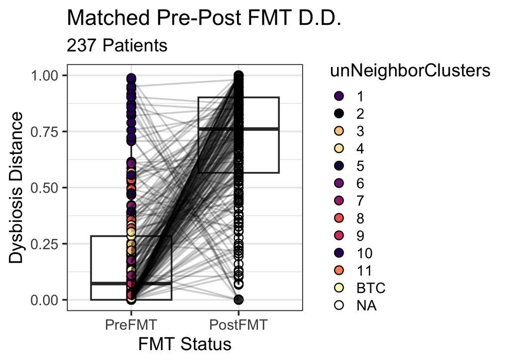

```r
FullChange
```

```r
((matchedDysDistNoBar) | BaseDDSig237Plot)+
  plot_layout(ncol = 2, widths = c(2.5, 1))->s7a

((DeltaBoxNoBar) | DeltaSig237Plot)+
  plot_layout(ncol = 2, widths = c(2.5, 1))->s7b

((normDeltaBoxNoBar) | normDeltaSig237Plot)+
  plot_layout(ncol = 2, widths = c(2.5, 1))->s7d


wrap_plots(s7a,s7b, SuppUnWtUni, s7d)->altSuppFig7

pdf("~/Desktop/Lozupone_022425/Keith/Metaanalysis/metaManuscript/UpdatedData082826/Supp_Fig7_090926.pdf", width = 15, height = 12)
altSuppFig7
dev.off()
```

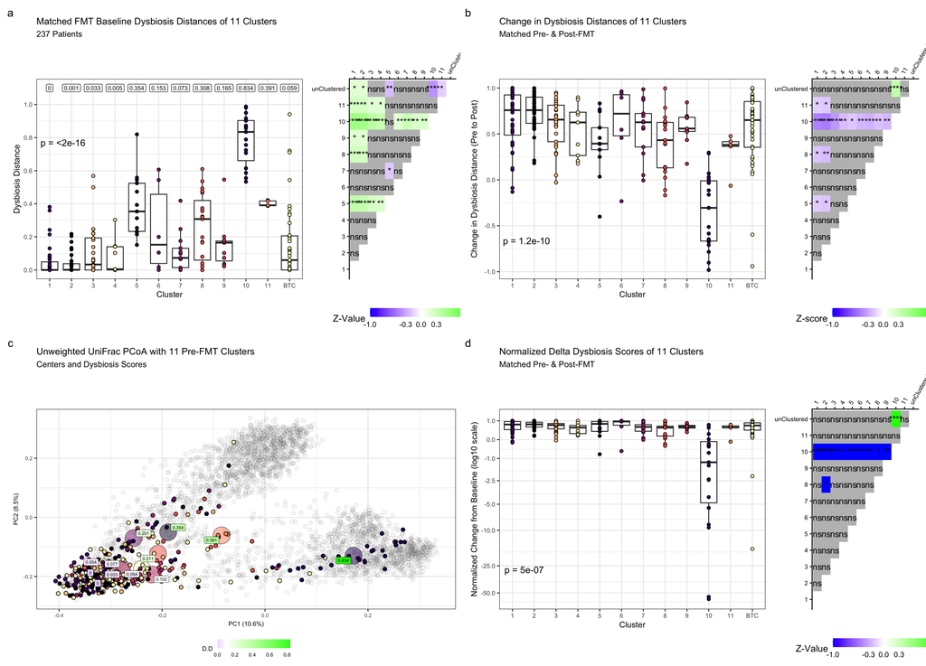

```r
altSuppFig7
```

```r
(matchedDysDistBox | matchedDeltaBox) / (SuppUnWtUni | normDDBox)->Fig7

pdf("~/Desktop/Lozupone_022425/Keith/Metaanalysis/metaManuscript/UpdatedData082826/Supp_Fig72_090926.pdf", width = 15, height = 12)
Fig7
dev.off()
```

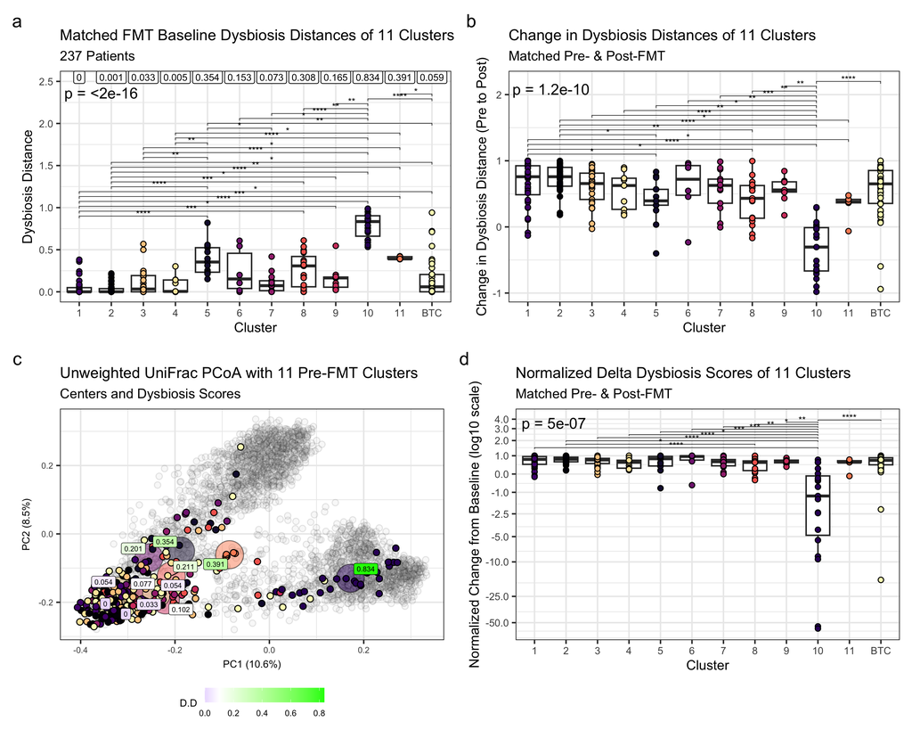

```r
Fig7
```

```r
pdf("~/Desktop/Lozupone_022425/Keith/Metaanalysis/metaManuscript/UpdatedData082826/ClusterFaithBoxPlot_090926.pdf", width = 11, height = 8.5)
#Faith for matched patients FMT plots/stats
normDistDiffPrePostMatchFMT  %>%
  ungroup() %>%
  filter(fmt_status == 'PreFMT') %>% #237 obs
  kruskal.test(data = ., FaithPD ~ unNeighborClusters)->my237DysFaithKruskal
print(my237DysFaithKruskal)
```

```
##
##  Kruskal-Wallis rank sum test
##
## data:  FaithPD by unNeighborClusters
## Kruskal-Wallis chi-squared = 118.45, df = 11, p-value < 2.2e-16
```

```r
normDistDiffPrePostMatchFMT  %>%
  ungroup() %>%
  filter(fmt_status == 'PreFMT') %>% #237 obs
  kruskal_effsize(data = ., FaithPD ~ unNeighborClusters)->my237DysFaithEffect
print(my237DysFaithEffect)
```

```
## # A tibble: 1 × 5
##   .y.         n effsize method  magnitude
## * <chr>   <int>   <dbl> <chr>   <ord>
## 1 FaithPD   237   0.478 eta2[H] large
```

```r
normDistDiffPrePostMatchFMT  %>%
  filter(fmt_status == 'PreFMT') %>% #237 obs
  dunn_test(data = ., FaithPD ~ unNeighborClusters, p.adjust.method = "BH",
            effect.size = TRUE)->my237FaithClusterDunn
write_tsv(my237FaithClusterDunn, "~/Desktop/Lozupone_022425/Keith/Metaanalysis/metaManuscript/UpdatedData082826/my237FaithClusterDunn_090926.tsv", quote = "none")

my237FaithClusterDunn %>%
    filter(p.adj.signif != 'ns') %>%
  select(group1,group2,p.adj.signif) %>%
  mutate(p.adj = p.adj.signif) %>%
  mutate(y.position = c(seq(80, 500, length.out = 32)))->Signif237FaithDunn

#boxplot of dysbio clusters and their starting faith PD for just matched patients
normDistDiffPrePostMatchFMT  %>%
  filter(fmt_status == 'PreFMT') %>% #237 obs
  ggplot(aes(y= FaithPD, x= unNeighborClusters)) +
  ggtitle("") +
    labs(title = "Matched FMT FaithPD Scores of 11 Clusters",
       subtitle = "237 Patients",
       x = "Cluster",
       y = "Faith PD",
       tag = "a") +
  theme_bw(base_size = 18) +
  geom_boxplot()+
  geom_point(aes(fill =unNeighborClusters), pch = 21, size =2.5)+
    stat_compare_means(method = "kruskal.test",label.y = 50, aes(label = paste0("p = ", after_stat(p.format)))) +
  stat_pvalue_manual(Signif237FaithDunn,tip.length = 0.001)+
        discrete_scale(aesthetics = "fill",
               palette = function(x) c(DysbioColors))+
    coord_trans(y = "pseudo_log", ylim = c(0,500))+
  scale_y_continuous(breaks = c(0,5,10,25,50,100,150,250,500))+
      scale_x_discrete(limits= labelVectorRedo)+
  theme(legend.position="none",
        axis.title.x = element_text(size = 16),
        axis.text.x = element_text(size = 12),
        axis.title.y = element_text(size = 16),
        axis.text.y = element_text(size = 12),
        plot.title = element_text( size = 18),
        plot.subtitle = element_text( size = 16),
        legend.margin = margin(t = 0, b = 0, r = 0, l = 0))->matchedFaithBox
matchedFaithBox

normDistDiffPrePostMatchFMT  %>%
  filter(fmt_status == 'PreFMT') %>% #237 obs
  ggplot(aes(y= FaithPD, x= unNeighborClusters)) +
  ggtitle("") +
    labs(title = "Matched FMT FaithPD Scores of 11 Clusters",
       subtitle = "237 Patients",
       x = "Cluster",
       y = "Faith PD",
       tag = "a") +
  theme_bw(base_size = 18) +
  geom_boxplot()+
  geom_point(aes(fill =unNeighborClusters), pch = 21, size =2.5)+
    stat_compare_means(method = "kruskal.test",label.y = 50, aes(label = paste0("p = ", after_stat(p.format)))) +
        discrete_scale(aesthetics = "fill",
               palette = function(x) c(DysbioColors))+
    coord_trans(y = "pseudo_log", ylim = c(0,150))+
  scale_y_continuous(breaks = c(0,5,10,25,50,100,150))+
      scale_x_discrete(limits= labelVectorRedo)+
  theme(legend.position="none",
        axis.title.x = element_text(size = 16),
        axis.text.x = element_text(size = 12),
        axis.title.y = element_text(size = 16),
        axis.text.y = element_text(size = 12),
        plot.title = element_text( size = 18),
        plot.subtitle = element_text( size = 16),
        legend.margin = margin(t = 0, b = 0, r = 0, l = 0))->matchedFaithBoxNoBar
matchedFaithBoxNoBar

my237FaithClusterDunn %>%
ggplot(aes(x = group1, y = group2)) +
      theme_classic(base_size = 18) +
  geom_tile(aes(fill = r ), alpha = 1)+
  geom_tile(data = . %>%
              filter(p.adj.signif == "ns"), fill = "grey")+
  scale_x_discrete(limits=c("1","2","3","4","5","6","7","8","9","10","11","unClustered"),position = "top")+
    scale_y_discrete(limits=c("1","2","3","4","5","6","7","8","9","10","11","unClustered"))+
  geom_text(aes(label = p.adj.signif))+
            scale_fill_gradientn(colors = c("blue", "white", "green"),
                            values = rescale(c(-1,0,1)),
                            breaks = c(-1,-0.3, 0, 0.3, 1),
                            limits = c(-1, 1),
                            oob = scales::squish,
                            guide = guide_colorbar(barwidth= unit(7, "cm"),
                                                    title = "Estimate"))+
  theme(legend.position="bottom",
        axis.title.x = element_blank(),
        axis.text.x = element_text(size = 12,angle = 60, hjust = 0),
        axis.title.y = element_blank(),
        axis.text.y = element_text(size = 12),
        plot.title = element_text( size = 18),
        plot.subtitle = element_text( size = 16),
        legend.margin = margin(t = 0, b = 0, r = 0, l = 0))->FaithBoxSigPlot
FaithBoxSigPlot
dev.off()
```

```r
((matchedFaithBoxNoBar) | FaithBoxSigPlot)+
  plot_layout(ncol = 2, widths = c(1.75, 0.75))->S8a


(FigS8balt4 | FigS8calt)+
  plot_layout(ncol = 2, widths = c(1.5, 1.5))->S8bc
```

```r
(S8a / S8bc)+
  plot_layout(nrow = 2, heights = c(0.75, 1))->SuppFig8

pdf("~/Desktop/Lozupone_022425/Keith/Metaanalysis/metaManuscript/UpdatedData082826/Supp_Fig8_090926.pdf", width = 15, height = 12)
SuppFig8
dev.off()
```

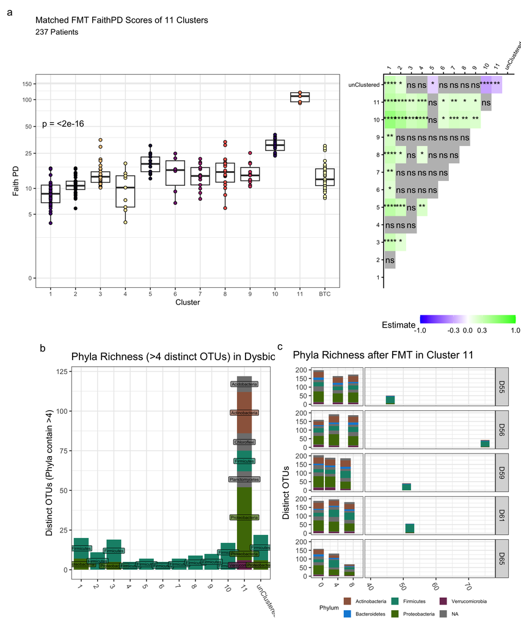

```r
SuppFig8
```

```r
PrePostMatchedFMT %>%
filter(unNeighborClusters != "NA") %>%
  group_by(target_subfragment) %>%
dplyr::count(unNeighborClusters) ->infoPreSubFrag

PrePostMatchedFMT %>%
filter(unNeighborClusters != "NA") ->PreMatchedData

SubfragDataPre<- table(PreMatchedData$unNeighborClusters, PreMatchedData$target_subfragment)
resultSubPre <- chisq.test(SubfragDataPre)
print(resultSubPre)
```

```
##
##  Pearson's Chi-squared test
##
## data:  SubfragDataPre
## X-squared = 203.91, df = 55, p-value < 2.2e-16
```

```r
#significant relationship (X-squared = 203.91, df = 55, p-value < 2.2e-16)
resultSubPre$expected
```

```
##
##                   V1-V3     V3-V4     V3-V5        V4     V5-V6        V6
##   1           0.8438819 2.3628692 2.1940928 13.333333 19.240506 2.0253165
##   2           0.7172996 2.0084388 1.8649789 11.333333 16.354430 1.7215190
##   3           0.6118143 1.7130802 1.5907173  9.666667 13.949367 1.4683544
##   4           0.1898734 0.5316456 0.4936709  3.000000  4.329114 0.4556962
##   5           0.2742616 0.7679325 0.7130802  4.333333  6.253165 0.6582278
##   6           0.1265823 0.3544304 0.3291139  2.000000  2.886076 0.3037975
##   7           0.2742616 0.7679325 0.7130802  4.333333  6.253165 0.6582278
##   8           0.4008439 1.1223629 1.0421941  6.333333  9.139241 0.9620253
##   9           0.2320675 0.6497890 0.6033755  3.666667  5.291139 0.5569620
##   10          0.4008439 1.1223629 1.0421941  6.333333  9.139241 0.9620253
##   11          0.1054852 0.2953586 0.2742616  1.666667  2.405063 0.2531646
##   unClustered 0.8227848 2.3037975 2.1392405 13.000000 18.759494 1.9746835
```

```r
cramResultSubPre<-cramer_v(SubfragDataPre)
print(cramResultSubPre)
```

```
## [1] 0.4148231
```

```r
#moderate effect size (0.4148)

PrePostMatchedFMT %>%
filter(unNeighborClusters != "NA") %>%
  group_by(experiment_title) %>%
dplyr::count(unNeighborClusters) ->infoPreStudy


pdf("~/Desktop/Lozupone_022425/Keith/Metaanalysis/metaManuscript/UpdatedData082826/MatchedFMTClusterDistributionPlots_090926.pdf", width = 11, height = 8.5)
infoPreSubFrag  %>%
  ggplot(aes(fill=target_subfragment, y= n, x= unNeighborClusters)) +
      ggtitle("Distribution of Subfragment for 11 Neighbor redo Dysbio clusters in PreFMT with matched Post") +
  geom_bar(position="stack", stat="identity")+
          discrete_scale(aesthetics = "fill",
               palette = function(x) c(PrimerColors))+
    scale_x_discrete(limits=labelVectorRedo)+
    theme(legend.position="none",
        axis.title.x = element_text(size = 16),
        axis.text.x = element_text(size = 12),
        axis.title.y = element_text(size = 16),
        axis.text.y = element_text(size = 12),
        plot.title = element_text( size = 18),
        plot.subtitle = element_text( size = 16),
        legend.margin = margin(t = 0, b = 0, r = 0, l = 0))->subFrag237

infoPreStudy  %>%
  ggplot(aes(fill=experiment_title, y= n, x= unNeighborClusters)) +
      ggtitle("Distribution of Studies for 11 redo Dysbio clusters in PreFMT with matched Post") +
    geom_bar(position="stack", stat="identity")+
          discrete_scale(aesthetics = "fill",
               palette = function(x) c(StudyColors))+
    scale_x_discrete(limits=labelVectorRedo)+
    theme(legend.position="none",
        axis.title.x = element_text(size = 16),
        axis.text.x = element_text(size = 12),
        axis.title.y = element_text(size = 16),
        axis.text.y = element_text(size = 12),
        plot.title = element_text( size = 18),
        plot.subtitle = element_text( size = 16),
        legend.margin = margin(t = 0, b = 0, r = 0, l = 0))->study237
dev.off()
```

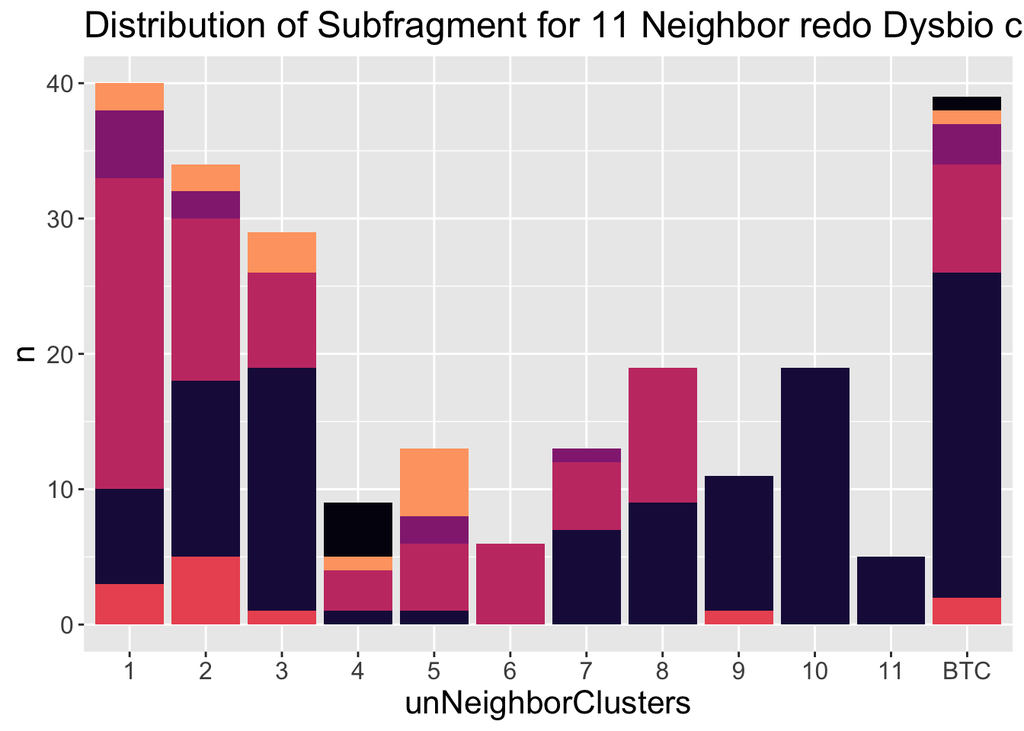

```r
subFrag237
```

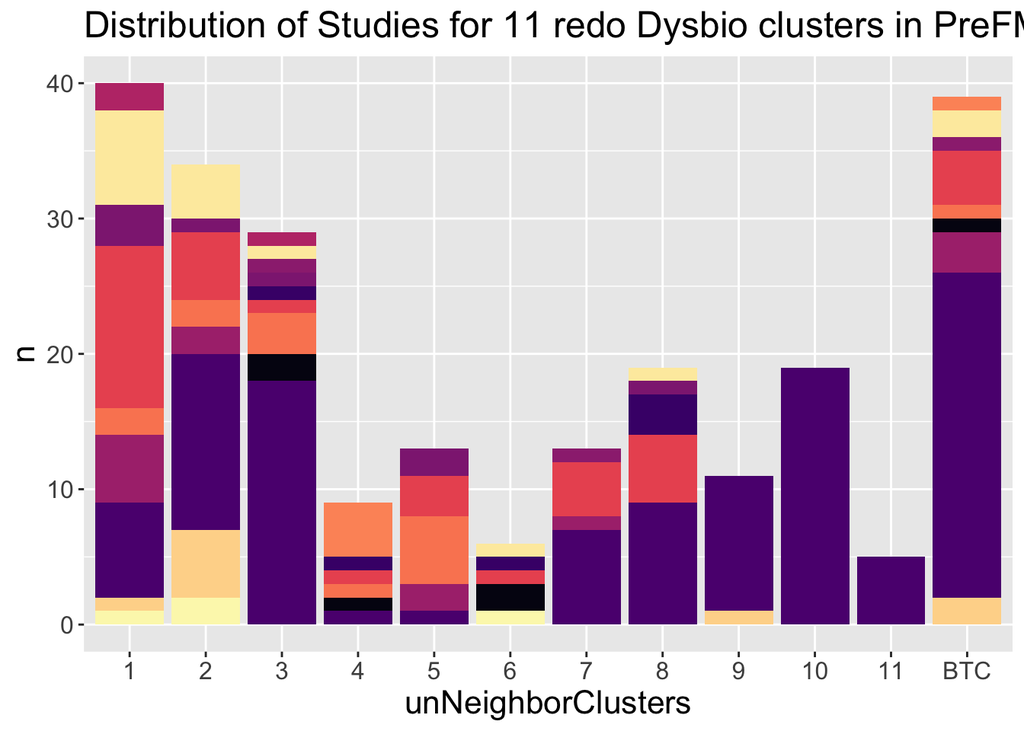

```r
study237
```

```r
StudyDataPre<- table(PreMatchedData$unNeighborClusters, PreMatchedData$experiment_title)
resultStudyPre <- chisq.test(StudyDataPre)
print(resultStudyPre)
```

```
##
##  Pearson's Chi-squared test
##
## data:  StudyDataPre
## X-squared = 307.11, df = 132, p-value = 5.47e-16
```

```r
#significant relationship (307.11, df = 132, p-value = 5.47e-16)
resultStudyPre$expected
```

```
##
##                  fricke Hamilton 2013  Hazleton  hong kong hourigan_2015
##   1           0.8438819    0.50632911 2.7004219 0.50632911     1.3502110
##   2           0.7172996    0.43037975 2.2953586 0.43037975     1.1476793
##   3           0.6118143    0.36708861 1.9578059 0.36708861     0.9789030
##   4           0.1898734    0.11392405 0.6075949 0.11392405     0.3037975
##   5           0.2742616    0.16455696 0.8776371 0.16455696     0.4388186
##   6           0.1265823    0.07594937 0.4050633 0.07594937     0.2025316
##   7           0.2742616    0.16455696 0.8776371 0.16455696     0.4388186
##   8           0.4008439    0.24050633 1.2827004 0.24050633     0.6413502
##   9           0.2320675    0.13924051 0.7426160 0.13924051     0.3713080
##   10          0.4008439    0.24050633 1.2827004 0.24050633     0.6413502
##   11          0.1054852    0.06329114 0.3375527 0.06329114     0.1687764
##   unClustered 0.8227848    0.49367089 2.6329114 0.49367089     1.3164557
##
```

[output cut: 27 more lines]

```r
cramResultStudyPre<-cramer_v(StudyDataPre)
print(cramResultStudyPre)
```

```
## [1] 0.3432246
```

```r
#moderate effect size (0.3432 )
```

LMEMs

```r
#this model will look at dysbiosis distance as the outcome variable and it will do so using patient as the random intercept, the null model will account for DRF. In one model we will include cluster, and in another we will add the interaction of cluster with DRF.
normDistDiffPrePostMatchFMT %>%
  group_by(study_hostID) %>%
    filter(day_relative_to_fmt2 > -89) %>%
    mutate(has_both = n_distinct(fmt_status) == 2) %>%
  filter(has_both == TRUE) %>%
  fill(unNeighborClusters, .direction = "downup") %>%
  ungroup() %>%
    lmer(dysbiosis_dist~ day_relative_to_fmt2 + (1|study_hostID),REML=FALSE, data = .)-> LongMENull_model
summary(LongMENull_model)
```

```
## Linear mixed model fit by maximum likelihood . t-tests use Satterthwaite's
##   method [lmerModLmerTest]
## Formula: dysbiosis_dist ~ day_relative_to_fmt2 + (1 | study_hostID)
##    Data: .
##
##       AIC       BIC    logLik -2*log(L)  df.resid
##     203.8     220.4     -97.9     195.8       468
##
## Scaled residuals:
##     Min      1Q  Median      3Q     Max
## -2.5183 -0.9222 -0.1844  0.8239  2.2913
##
## Random effects:
##  Groups       Name        Variance Std.Dev.
##  study_hostID (Intercept) 0.00000  0.0000
##  Residual                 0.08865  0.2977
## Number of obs: 472, groups:  study_hostID, 236
##
## Fixed effects:
##                       Estimate Std. Error        df t value Pr(>|t|)
## (Intercept)          3.057e-01  1.660e-02 4.720e+02   18.42   <2e-16 ***
## day_relative_to_fmt2 7.930e-03  5.351e-04 4.720e+02   14.82   <2e-16 ***
## ---
## Signif. codes:  0 '***' 0.001 '**' 0.01 '*' 0.05 '.' 0.1 ' ' 1
##
## Correlation of Fixed Effects:
##             (Intr)
## dy_rltv_t_2 -0.564
## optimizer (nloptwrap) convergence code: 0 (OK)
## boundary (singular) fit: see help('isSingular')
```

```r
normDistDiffPrePostMatchFMT %>%
  group_by(study_hostID) %>%
    filter(day_relative_to_fmt2 > -89) %>%
    mutate(has_both = n_distinct(fmt_status) == 2) %>%
  filter(has_both == TRUE) %>%
  fill(unNeighborClusters, .direction = "downup") %>%
  ungroup() %>%
    lmer(dysbiosis_dist~ day_relative_to_fmt2 + unNeighborClusters + (1|study_hostID), data = .)-> LongMENoIntX_model
summary(LongMENoIntX_model)
```

```
## Linear mixed model fit by REML. t-tests use Satterthwaite's method [
## lmerModLmerTest]
## Formula: dysbiosis_dist ~ day_relative_to_fmt2 + unNeighborClusters +
##     (1 | study_hostID)
##    Data: .
##
## REML criterion at convergence: 220.5
##
## Scaled residuals:
##     Min      1Q  Median      3Q     Max
## -2.6574 -0.7931 -0.1715  0.8161  2.3489
##
## Random effects:
##  Groups       Name        Variance Std.Dev.
##  study_hostID (Intercept) 0.00000  0.00
##  Residual                 0.08411  0.29
## Number of obs: 472, groups:  study_hostID, 236
##
## Fixed effects:
##                                 Estimate Std. Error         df t value Pr(>|t|)
## (Intercept)                    2.381e-01  3.371e-02  4.590e+02   7.063 6.09e-12
## day_relative_to_fmt2           8.068e-03  5.234e-04  4.590e+02  15.416  < 2e-16
## unNeighborClusters2            2.912e-02  4.784e-02  4.590e+02   0.609 0.542990
## unNeighborClusters3            1.243e-02  5.004e-02  4.590e+02   0.248 0.803913
## unNeighborClusters4           -4.459e-02  7.566e-02  4.590e+02  -0.589 0.555942
## unNeighborClusters5            2.376e-01  6.549e-02  4.590e+02   3.628 0.000318
## unNeighborClusters6            1.155e-01  8.983e-02  4.590e+02   1.286 0.199241
## unNeighborClusters7            1.595e-02  6.547e-02  4.590e+02   0.244 0.807652
## unNeighborClusters8            1.128e-01  5.718e-02  4.590e+02   1.972 0.049215
## unNeighborClusters9            4.958e-02  6.982e-02  4.590e+02   0.710 0.477983
## unNeighborClusters10           2.583e-01  5.715e-02  4.590e+02   4.520 7.89e-06
## unNeighborClusters11           1.386e-01  9.731e-02  4.590e+02   1.424 0.155021
## unNeighborClustersunClustered  5.686e-02  4.646e-02  4.590e+02   1.224 0.221642
##
## (Intercept)                   ***
## day_relative_to_fmt2          ***
## unNeighborClusters2
## unNeighborClusters3
## unNeighborClusters4
## unNeighborClusters5           ***
## unNeighborClusters6
## unNeighborClusters7
## unNeighborClusters8           *
## unNeighborClusters9
## unNeighborClusters10          ***
## unNeighborClusters11
## unNeighborClustersunClustered
## ---
## Signif. codes:  0 '***' 0.001 '**' 0.01 '*' 0.05 '.' 0.1 ' ' 1
```

```
## optimizer (nloptwrap) convergence code: 0 (OK)
## boundary (singular) fit: see help('isSingular')
```

```r
normDistDiffPrePostMatchFMT %>%
  group_by(study_hostID) %>%
    filter(day_relative_to_fmt2 > -89) %>%
    mutate(has_both = n_distinct(fmt_status) == 2) %>%
  filter(has_both == TRUE) %>%
  fill(unNeighborClusters, .direction = "downup") %>%
  ungroup() %>%
    lmer(dysbiosis_dist~ day_relative_to_fmt2 * unNeighborClusters + (1|study_hostID),data = .)-> LongMENeighbor_model
summary(LongMENeighbor_model)
```

```
## Linear mixed model fit by REML. t-tests use Satterthwaite's method [
## lmerModLmerTest]
## Formula: dysbiosis_dist ~ day_relative_to_fmt2 * unNeighborClusters +
##     (1 | study_hostID)
##    Data: .
##
## REML criterion at convergence: 301.3
##
## Scaled residuals:
##     Min      1Q  Median      3Q     Max
## -2.6605 -0.7396 -0.1971  0.8029  2.4726
##
## Random effects:
##  Groups       Name        Variance Std.Dev.
##  study_hostID (Intercept) 0.00000  0.0000
##  Residual                 0.08005  0.2829
## Number of obs: 472, groups:  study_hostID, 236
##
## Fixed effects:
##                                                      Estimate Std. Error
## (Intercept)                                         2.092e-01  3.835e-02
## day_relative_to_fmt2                                9.705e-03  1.231e-03
## unNeighborClusters2                                 1.826e-02  5.617e-02
## unNeighborClusters3                                 3.632e-02  6.018e-02
## unNeighborClusters4                                -1.288e-02  8.940e-02
## unNeighborClusters5                                 2.860e-01  7.436e-02
## unNeighborClusters6                                 1.381e-01  1.074e-01
## unNeighborClusters7                                 7.316e-02  7.625e-02
## unNeighborClusters8                                 1.292e-01  6.728e-02
## unNeighborClusters9                                 7.788e-02  8.278e-02
## unNeighborClusters10                                4.663e-01  6.879e-02
## unNeighborClusters11                                1.931e-01  1.208e-01
## unNeighborClustersunClustered                       7.433e-02  5.522e-02
## day_relative_to_fmt2:unNeighborClusters2            7.082e-04  1.813e-03
## day_relative_to_fmt2:unNeighborClusters3           -1.395e-03  1.833e-03
## day_relative_to_fmt2:unNeighborClusters4           -1.787e-03  2.670e-03
## day_relative_to_fmt2:unNeighborClusters5           -2.997e-03  2.501e-03
## day_relative_to_fmt2:unNeighborClusters6           -1.373e-03  2.775e-03
## day_relative_to_fmt2:unNeighborClusters7           -3.361e-03  2.486e-03
## day_relative_to_fmt2:unNeighborClusters8           -7.061e-04  2.625e-03
```

[output cut: 41 more lines]

```
## unNeighborClusters11
## unNeighborClustersunClustered
## day_relative_to_fmt2:unNeighborClusters2
## day_relative_to_fmt2:unNeighborClusters3
## day_relative_to_fmt2:unNeighborClusters4
## day_relative_to_fmt2:unNeighborClusters5
## day_relative_to_fmt2:unNeighborClusters6
## day_relative_to_fmt2:unNeighborClusters7
## day_relative_to_fmt2:unNeighborClusters8
## day_relative_to_fmt2:unNeighborClusters9
## day_relative_to_fmt2:unNeighborClusters10          ***
## day_relative_to_fmt2:unNeighborClusters11
## day_relative_to_fmt2:unNeighborClustersunClustered
## ---
## Signif. codes:  0 '***' 0.001 '**' 0.01 '*' 0.05 '.' 0.1 ' ' 1
```

```
## optimizer (nloptwrap) convergence code: 0 (OK)
## boundary (singular) fit: see help('isSingular')
```

```r
as.data.frame(summary(LongMENeighbor_model)$coefficients) %>%
  rownames_to_column("terms")->DRFXClusterRTb

 write_tsv(DRFXClusterRTb, "~/Desktop/Lozupone_022425/Keith/Metaanalysis/metaManuscript/UpdatedData082826/DRFXCluster_090926.tsv", quote = "none")

 normDistDiffPrePostMatchFMT %>%
  group_by(study_hostID) %>%
    filter(day_relative_to_fmt2 > -89) %>%
    mutate(has_both = n_distinct(fmt_status) == 2) %>%
  filter(has_both == TRUE) %>%
  fill(unNeighborClusters, .direction = "downup") %>%
  ungroup() %>%
    lmer(dysbiosis_dist~ day_relative_to_fmt2 + unNeighborClusters + (1|study_hostID), REML=FALSE, data = .)-> LongMENoIntX_model2

anova(LongMENull_model,LongMENoIntX_model2)->aovCluster
print(aovCluster)
```

```
## Data: .
## Models:
## LongMENull_model: dysbiosis_dist ~ day_relative_to_fmt2 + (1 | study_hostID)
## LongMENoIntX_model2: dysbiosis_dist ~ day_relative_to_fmt2 + unNeighborClusters + (1 | study_hostID)
##                     npar    AIC    BIC  logLik -2*log(L)  Chisq Df Pr(>Chisq)
## LongMENull_model       4 203.80 220.43 -97.900    195.80
## LongMENoIntX_model2   15 187.82 250.17 -78.909    157.82 37.982 11  7.879e-05
##
## LongMENull_model
## LongMENoIntX_model2 ***
## ---
## Signif. codes:  0 '***' 0.001 '**' 0.01 '*' 0.05 '.' 0.1 ' ' 1
```

```r
 write_tsv(aovCluster %>%
              rownames_to_column("Model"),"~/Desktop/Lozupone_022425/Keith/Metaanalysis/metaManuscript/UpdatedData082826/DRFandClusterAOV_090926.tsv", quote = "none")

normDistDiffPrePostMatchFMT %>%
  group_by(study_hostID) %>%
    filter(day_relative_to_fmt2 > -89) %>%
    mutate(has_both = n_distinct(fmt_status) == 2) %>%
  filter(has_both == TRUE) %>%
  fill(unNeighborClusters, .direction = "downup") %>%
  ungroup() %>%
    lmer(dysbiosis_dist~ day_relative_to_fmt2 * unNeighborClusters + (1|study_hostID),REML=FALSE,data = .)-> LongMENeighbor_model2

anova(LongMENoIntX_model2, LongMENeighbor_model2)->aovDRFxCluster
print(aovDRFxCluster)
```

```
## Data: .
## Models:
## LongMENoIntX_model2: dysbiosis_dist ~ day_relative_to_fmt2 + unNeighborClusters + (1 | study_hostID)
## LongMENeighbor_model2: dysbiosis_dist ~ day_relative_to_fmt2 * unNeighborClusters + (1 | study_hostID)
##                       npar    AIC    BIC  logLik -2*log(L)  Chisq Df Pr(>Chisq)
## LongMENoIntX_model2     15 187.82 250.17 -78.909    157.82
## LongMENeighbor_model2   26 175.01 283.10 -61.507    123.01 34.805 11  0.0002668
##
## LongMENoIntX_model2
## LongMENeighbor_model2 ***
## ---
## Signif. codes:  0 '***' 0.001 '**' 0.01 '*' 0.05 '.' 0.1 ' ' 1
```

```r
write_tsv(aovDRFxCluster %>%
             rownames_to_column("Model"), "~/Desktop/Lozupone_022425/Keith/Metaanalysis/metaManuscript/UpdatedData082826/DRFXClusterAOV_090126.tsv", quote = "none")

TrendsDDIntX <- emtrends(LongMENeighbor_model, "unNeighborClusters", var = "day_relative_to_fmt2")
pairs(TrendsDDIntX,adjust = "BH") %>%
        # summary()->DDTrendsCorrectedPairComps
as.data.frame() %>%
  separate_wider_delim(., cols = contrast, delim = "-", names = c("Comp1","Comp2")) %>%
  mutate(Comp1 = str_replace_all(Comp1, " ", "")) %>%
  mutate(Comp2 = str_replace_all(Comp2, " ", "")) ->DDSlopeTable

DDSlopeTable %>%
  mutate(signif = symnum(DDSlopeTable$p.value,
                                   cutpoints = c(0, 0.0001, 0.001, 0.01, 0.05, 1),
                                   symbols = c("****", "***", "**", "*", "ns"),
                                   abbr.colnames = FALSE,
                                   na = ""))->DDSlopeTableSig

pdf("~/Desktop/Lozupone_022425/Keith/Metaanalysis/metaManuscript/UpdatedData082826/DDSlopePairwisePlot_090926.pdf", width = 11, height = 8.5)
DDSlopeTableSig %>%
ggplot(aes(x = Comp1, y = Comp2), alpha = 0.3) +
      theme_classic(base_size = 18) +
  geom_tile(aes(fill = estimate))+
  geom_tile(data = . %>%
              filter(signif == "ns"), fill = "grey")+
  scale_x_discrete(limits=c("1","2","3","4","5","6","7","8","9","10","11","unClustered"),position = "top")+
    scale_y_discrete(limits=c("1","2","3","4","5","6","7","8","9","10","11","unClustered"))+
  geom_text(aes(label = signif))+
            scale_fill_gradientn(colors = c("blue", "white","green"),
                            values = rescale(c(0.1, 0.05,0.001)),
                            breaks = c(0.1,0.05, 0),
                            trans = "pseudo_log",
                            limits = c(0, 0.1),
                            oob = scales::squish,
                            guide = guide_colorbar(barwidth= unit(5, "cm"),
                                                    title = "Significance"))+
  theme(legend.position="bottom",
        axis.title.x = element_blank(),
        axis.text.x = element_text(size = 12,angle = 60, hjust = 0),
        axis.title.y = element_blank(),
        axis.text.y = element_text(size = 12),
        plot.title = element_text( size = 18),
        plot.subtitle = element_text( size = 16),
        legend.margin = margin(t = 0, b = 0, r = 0, l = 0))->DDSignifPlot
DDSignifPlot

DDSlopeTableSig %>%
ggplot(aes(x = Comp1, y = Comp2)) +
      theme_classic(base_size = 18) +
  geom_tile(aes(fill = estimate), alpha = 0.8)+
  geom_tile(data = . %>%
              filter(signif == "ns"), fill = "grey")+
  scale_x_discrete(limits=c("1","2","3","4","5","6","7","8","9","10","11","unClustered"),position = "top")+
    scale_y_discrete(limits=c("1","2","3","4","5","6","7","8","9","10","11","unClustered"))+
  geom_text(aes(label = signif))+
            scale_fill_gradientn(colors = c("blue", "green"),
                            values = rescale(c(-2,0,.5)),
                            breaks = c(-2,-1.5,-1, -0.5, 0, 0.5),
                            limits = c(-2, 0.5),
                            oob = scales::squish,
                            guide = guide_colorbar(barwidth= unit(5, "cm"),
                                                    title = "Estimate"))+
  theme(legend.position="none",
        axis.title.x = element_blank(),
        axis.text.x = element_text(size = 12,angle = 60, hjust = 0),
        axis.title.y = element_blank(),
        axis.text.y = element_text(size = 12),
        plot.title = element_text( size = 18),
        plot.subtitle = element_text( size = 16),
        legend.margin = margin(t = 0, b = 0, r = 0, l = 0))->DDSigEstPlot
DDSigEstPlot
dev.off()
```

```r
emtrends(LongMENeighbor_model, pairwise ~ unNeighborClusters,
         var = "day_relative_to_fmt2",adjust = "BH")->eSlopeClustDD
eSlopeClustDD$emtrends %>%
  summary()->slopeClustEmTrends
eSlopeClustDD$contrasts %>%
  summary()->slopeClustContrasts
```

Faith as outcome

```r
normDistDiffPrePostMatchFMT %>%
  group_by(study_hostID) %>%
    filter(day_relative_to_fmt2 > -89) %>%
    mutate(has_both = n_distinct(fmt_status) == 2) %>%
  filter(has_both == TRUE) %>%
  fill(unNeighborClusters, .direction = "downup") %>%
  ungroup() %>%
    lmer(FaithPD~ day_relative_to_fmt2 + (1|study_hostID), REML=FALSE, data = .)-> FaithNull_model
summary(FaithNull_model)
```

```
## Linear mixed model fit by maximum likelihood . t-tests use Satterthwaite's
##   method [lmerModLmerTest]
## Formula: FaithPD ~ day_relative_to_fmt2 + (1 | study_hostID)
##    Data: .
##
##       AIC       BIC    logLik -2*log(L)  df.resid
##    3736.3    3753.0   -1864.2    3728.3       468
##
## Scaled residuals:
##     Min      1Q  Median      3Q     Max
## -1.9198 -0.6287 -0.1638  0.4374  8.0424
##
## Random effects:
##  Groups       Name        Variance Std.Dev.
##  study_hostID (Intercept)   0.2138  0.4624
##  Residual                 157.5601 12.5523
## Number of obs: 472, groups:  study_hostID, 236
##
## Fixed effects:
##                       Estimate Std. Error        df t value Pr(>|t|)
## (Intercept)           19.18874    0.70049 368.46261   27.39  < 2e-16 ***
## day_relative_to_fmt2   0.16611    0.02257 372.31792    7.36 1.18e-12 ***
## ---
## Signif. codes:  0 '***' 0.001 '**' 0.01 '*' 0.05 '.' 0.1 ' ' 1
##
## Correlation of Fixed Effects:
##             (Intr)
## dy_rltv_t_2 -0.564
```

```r
normDistDiffPrePostMatchFMT %>%
  group_by(study_hostID) %>%
    filter(day_relative_to_fmt2 > -89) %>%
    mutate(has_both = n_distinct(fmt_status) == 2) %>%
  filter(has_both == TRUE) %>%
  fill(unNeighborClusters, .direction = "downup") %>%
  ungroup() %>%
    lmer(FaithPD~ day_relative_to_fmt2 + unNeighborClusters + (1|study_hostID), data = .)-> LongMEFaithNoIntX_model
summary(LongMEFaithNoIntX_model)
```

```
## Linear mixed model fit by REML. t-tests use Satterthwaite's method [
## lmerModLmerTest]
## Formula:
## FaithPD ~ day_relative_to_fmt2 + unNeighborClusters + (1 | study_hostID)
##    Data: .
##
## REML criterion at convergence: 3500.4
##
## Scaled residuals:
##     Min      1Q  Median      3Q     Max
## -4.8138 -0.6402 -0.0831  0.5815  5.2702
##
## Random effects:
##  Groups       Name        Variance Std.Dev.
##  study_hostID (Intercept)   0.0     0.00
##  Residual                 106.7    10.33
## Number of obs: 472, groups:  study_hostID, 236
##
## Fixed effects:
##                                Estimate Std. Error        df t value Pr(>|t|)
## (Intercept)                    15.01746    1.20081 459.00000  12.506  < 2e-16
## day_relative_to_fmt2            0.16060    0.01864 459.00000   8.614  < 2e-16
## unNeighborClusters2             1.73026    1.70408 459.00000   1.015  0.31047
## unNeighborClusters3             4.07198    1.78244 459.00000   2.284  0.02280
## unNeighborClusters4            -1.07387    2.69529 459.00000  -0.398  0.69050
## unNeighborClusters5             6.57654    2.33298 459.00000   2.819  0.00503
## unNeighborClusters6             3.99179    3.20002 459.00000   1.247  0.21288
## unNeighborClusters7             1.96544    2.33231 459.00000   0.843  0.39983
## unNeighborClusters8             3.85013    2.03700 459.00000   1.890  0.05937
## unNeighborClusters9             4.87593    2.48724 459.00000   1.960  0.05056
## unNeighborClusters10            9.65240    2.03593 459.00000   4.741 2.84e-06
## unNeighborClusters11           50.80782    3.46640 459.00000  14.657  < 2e-16
## unNeighborClustersunClustered   3.70283    1.65485 459.00000   2.238  0.02573
##
## (Intercept)                   ***
## day_relative_to_fmt2          ***
## unNeighborClusters2
## unNeighborClusters3           *
## unNeighborClusters4
## unNeighborClusters5           **
## unNeighborClusters6
## unNeighborClusters7
## unNeighborClusters8           .
## unNeighborClusters9           .
## unNeighborClusters10          ***
## unNeighborClusters11          ***
## unNeighborClustersunClustered *
## ---
## Signif. codes:  0 '***' 0.001 '**' 0.01 '*' 0.05 '.' 0.1 ' ' 1
```

```
## optimizer (nloptwrap) convergence code: 0 (OK)
## boundary (singular) fit: see help('isSingular')
```

```r
normDistDiffPrePostMatchFMT %>%
  group_by(study_hostID) %>%
    filter(day_relative_to_fmt2 > -89) %>%
    mutate(has_both = n_distinct(fmt_status) == 2) %>%
  filter(has_both == TRUE) %>%
  fill(unNeighborClusters, .direction = "downup") %>%
  ungroup() %>%
    lmer(FaithPD~ day_relative_to_fmt2 * unNeighborClusters + (1|study_hostID),data = .)-> LongMEFaithIntX_model
summary(LongMEFaithIntX_model)
```

```
## Linear mixed model fit by REML. t-tests use Satterthwaite's method [
## lmerModLmerTest]
## Formula:
## FaithPD ~ day_relative_to_fmt2 * unNeighborClusters + (1 | study_hostID)
##    Data: .
##
## REML criterion at convergence: 3351.8
##
## Scaled residuals:
##     Min      1Q  Median      3Q     Max
## -5.0966 -0.6778 -0.1464  0.6339  2.8768
##
## Random effects:
##  Groups       Name        Variance Std.Dev.
##  study_hostID (Intercept)  0.00    0.000
##  Residual                 72.54    8.517
## Number of obs: 472, groups:  study_hostID, 236
##
## Fixed effects:
##                                                     Estimate Std. Error
## (Intercept)                                         13.17710    1.15453
## day_relative_to_fmt2                                 0.26509    0.03707
## unNeighborClusters2                                  2.22451    1.69083
## unNeighborClusters3                                  5.18575    1.81140
## unNeighborClusters4                                  0.32259    2.69095
## unNeighborClusters5                                  9.05249    2.23846
## unNeighborClusters6                                  5.40505    3.23244
## unNeighborClusters7                                  3.95931    2.29510
## unNeighborClusters8                                  4.45085    2.02531
## unNeighborClusters9                                  5.95599    2.49170
## unNeighborClusters10                                14.96192    2.07074
## unNeighborClusters11                                83.04308    3.63619
## unNeighborClustersunClustered                        4.80485    1.66218
## day_relative_to_fmt2:unNeighborClusters2            -0.02496    0.05456
## day_relative_to_fmt2:unNeighborClusters3            -0.06893    0.05518
## day_relative_to_fmt2:unNeighborClusters4            -0.08140    0.08036
## day_relative_to_fmt2:unNeighborClusters5            -0.14868    0.07527
## day_relative_to_fmt2:unNeighborClusters6            -0.08625    0.08352
## day_relative_to_fmt2:unNeighborClusters7            -0.11382    0.07482
## day_relative_to_fmt2:unNeighborClusters8            -0.01121    0.07902
```

[output cut: 41 more lines]

```
## unNeighborClusters11                               ***
## unNeighborClustersunClustered                      **
## day_relative_to_fmt2:unNeighborClusters2
## day_relative_to_fmt2:unNeighborClusters3
## day_relative_to_fmt2:unNeighborClusters4
## day_relative_to_fmt2:unNeighborClusters5           *
## day_relative_to_fmt2:unNeighborClusters6
## day_relative_to_fmt2:unNeighborClusters7
## day_relative_to_fmt2:unNeighborClusters8
## day_relative_to_fmt2:unNeighborClusters9
## day_relative_to_fmt2:unNeighborClusters10          ***
## day_relative_to_fmt2:unNeighborClusters11          ***
## day_relative_to_fmt2:unNeighborClustersunClustered
## ---
## Signif. codes:  0 '***' 0.001 '**' 0.01 '*' 0.05 '.' 0.1 ' ' 1
```

```
## optimizer (nloptwrap) convergence code: 0 (OK)
## boundary (singular) fit: see help('isSingular')
```

```r
as.data.frame(summary(LongMEFaithIntX_model)$coefficients) %>%
  rownames_to_column("terms")->DRFXClusterFaithTb

 write_tsv(DRFXClusterFaithTb, "~/Desktop/Lozupone_022425/Keith/Metaanalysis/metaManuscript/UpdatedData082826/DRFXClusterFaith_090926.tsv", quote = "none")
#REML FALSE for stats
 normDistDiffPrePostMatchFMT %>%
  group_by(study_hostID) %>%
    filter(day_relative_to_fmt2 > -89) %>%
    mutate(has_both = n_distinct(fmt_status) == 2) %>%
  filter(has_both == TRUE) %>%
  fill(unNeighborClusters, .direction = "downup") %>%
  ungroup() %>%
    lmer(FaithPD~ day_relative_to_fmt2 + unNeighborClusters + (1|study_hostID), REML=FALSE, data = .)->LongMEFaithNoIntX_model2

  normDistDiffPrePostMatchFMT %>%
  group_by(study_hostID) %>%
    filter(day_relative_to_fmt2 > -89) %>%
    mutate(has_both = n_distinct(fmt_status) == 2) %>%
  filter(has_both == TRUE) %>%
  fill(unNeighborClusters, .direction = "downup") %>%
  ungroup() %>%
    lmer(FaithPD~ day_relative_to_fmt2 * unNeighborClusters + (1|study_hostID), REML=FALSE, data = .)->LongMEFaithIntX_model2

anova(FaithNull_model,LongMEFaithNoIntX_model2)->aovFaithCluster
summary(aovFaithCluster)
```

```
##       npar            AIC            BIC           logLik        -2*log(L)
##  Min.   : 4.00   Min.   :3561   Min.   :3623   Min.   :-1864   Min.   :3531
##  1st Qu.: 6.75   1st Qu.:3605   1st Qu.:3656   1st Qu.:-1839   1st Qu.:3580
##  Median : 9.50   Median :3649   Median :3688   Median :-1815   Median :3630
##  Mean   : 9.50   Mean   :3649   Mean   :3688   Mean   :-1815   Mean   :3630
##  3rd Qu.:12.25   3rd Qu.:3692   3rd Qu.:3720   3rd Qu.:-1790   3rd Qu.:3679
##  Max.   :15.00   Max.   :3736   Max.   :3753   Max.   :-1765   Max.   :3728
##
##      Chisq             Df       Pr(>Chisq)
##  Min.   :197.7   Min.   :11   Min.   :0
##  1st Qu.:197.7   1st Qu.:11   1st Qu.:0
##  Median :197.7   Median :11   Median :0
##  Mean   :197.7   Mean   :11   Mean   :0
##  3rd Qu.:197.7   3rd Qu.:11   3rd Qu.:0
##  Max.   :197.7   Max.   :11   Max.   :0
##  NA's   :1       NA's   :1    NA's   :1
```

```r
 write_tsv(aovFaithCluster %>%
              rownames_to_column("Model"),"~/Desktop/Lozupone_022425/Keith/Metaanalysis/metaManuscript/UpdatedData082826/FaithDRFandClusterAOV_090926.tsv", quote = "none")
anova(LongMEFaithNoIntX_model2, LongMEFaithIntX_model2)->aovDRFxClusterFaith
summary(aovDRFxClusterFaith)
```

```
##       npar            AIC            BIC           logLik        -2*log(L)
##  Min.   :15.00   Min.   :3389   Min.   :3497   Min.   :-1765   Min.   :3337
##  1st Qu.:17.75   1st Qu.:3432   1st Qu.:3529   1st Qu.:-1741   1st Qu.:3385
##  Median :20.50   Median :3475   Median :3560   Median :-1717   Median :3434
##  Mean   :20.50   Mean   :3475   Mean   :3560   Mean   :-1717   Mean   :3434
##  3rd Qu.:23.25   3rd Qu.:3518   3rd Qu.:3592   3rd Qu.:-1693   3rd Qu.:3482
##  Max.   :26.00   Max.   :3561   Max.   :3623   Max.   :-1668   Max.   :3531
##
##      Chisq             Df       Pr(>Chisq)
##  Min.   :193.8   Min.   :11   Min.   :0
##  1st Qu.:193.8   1st Qu.:11   1st Qu.:0
##  Median :193.8   Median :11   Median :0
##  Mean   :193.8   Mean   :11   Mean   :0
##  3rd Qu.:193.8   3rd Qu.:11   3rd Qu.:0
##  Max.   :193.8   Max.   :11   Max.   :0
##  NA's   :1       NA's   :1    NA's   :1
```

```r
  write_tsv(aovDRFxClusterFaith %>%
               rownames_to_column("Model"), "~/Desktop/Lozupone_022425/Keith/Metaanalysis/metaManuscript/UpdatedData082826/FaithDRFXClusterAOV_090926.tsv", quote = "none")

# Multiple Test Correction with least square means in mixed models
TrendsFaithIntX <- emtrends(LongMEFaithIntX_model, "unNeighborClusters", var = "day_relative_to_fmt2")
pairs(TrendsFaithIntX,adjust = "BH") %>%
        # summary()->DDTrendsCorrectedPairComps
as.data.frame() %>%
  separate_wider_delim(., cols = contrast, delim = "-", names = c("Comp1","Comp2")) %>%
  mutate(Comp1 = str_replace_all(Comp1, " ", "")) %>%
  mutate(Comp2 = str_replace_all(Comp2, " ", "")) ->FaithSlopeTable

FaithSlopeTable %>%
  mutate(signif = symnum(FaithSlopeTable$p.value,
                                   cutpoints = c(0, 0.0001, 0.001, 0.01, 0.05, 1),
                                   symbols = c("****", "***", "**", "*", "ns"),
                                   abbr.colnames = FALSE,
                                   na = ""))->FaithSlopeTableSig

pdf("~/Desktop/Lozupone_022425/Keith/Metaanalysis/metaManuscript/UpdatedData082826/FaithSlopePairwisePlot_090926.pdf", width = 11, height = 8.5)
FaithSlopeTableSig %>%
ggplot(aes(x = Comp1, y = Comp2), alpha = 0.3) +
      theme_classic(base_size = 18) +
  geom_tile(aes(fill = p.value))+
#  geom_tile(data = . %>%
              #filter(signif == "ns"), fill = "grey")+
  scale_x_discrete(limits=c("1","2","3","4","5","6","7","8","9","10","11","unClustered"),position = "top")+
    scale_y_discrete(limits=c("1","2","3","4","5","6","7","8","9","10","11","unClustered"))+
  geom_text(aes(label = signif))+
            scale_fill_gradientn(colors = c("grey", "white","green"),
                            values = rescale(c(0.1, 0.05,0.001)),
                            breaks = c(0.1,0.05, 0),
                            trans = "pseudo_log",
                            limits = c(0, 0.1),
                            oob = scales::squish,
                            guide = guide_colorbar(barwidth= unit(5, "cm"),
                                                    title = "Significance"))+
  theme(legend.position="bottom",
        axis.title.x = element_blank(),
        axis.text.x = element_text(size = 12,angle = 60, hjust = 0),
        axis.title.y = element_blank(),
        axis.text.y = element_text(size = 12),
        plot.title = element_text( size = 18),
        plot.subtitle = element_text( size = 16),
        legend.margin = margin(t = 0, b = 0, r = 0, l = 0))->FaithSignifPlot
FaithSignifPlot

FaithSlopeTableSig %>%
ggplot(aes(x = Comp1, y = Comp2)) +
      theme_classic(base_size = 18) +
  geom_tile(aes(fill = estimate), alpha = 0.8)+
  geom_tile(data = . %>%
              filter(signif == "ns"), fill = "grey")+
  scale_x_discrete(limits=c("1","2","3","4","5","6","7","8","9","10","11","unClustered"),position = "top")+
    scale_y_discrete(limits=c("1","2","3","4","5","6","7","8","9","10","11","unClustered"))+
  geom_text(aes(label = signif))+
            scale_fill_gradientn(colors = c("blue", "green"),
                            values = rescale(c(-2,0,.5)),
                            breaks = c(-2,-1.5,-1, -0.5, 0, 0.5),
                            limits = c(-2, 0.5),
                            oob = scales::squish,
                            guide = guide_colorbar(barwidth= unit(5, "cm"),
                                                    title = "Estimate"))+
  theme(legend.position="bottom",
        axis.title.x = element_blank(),
        axis.text.x = element_text(size = 12,angle = 60, hjust = 0),
        axis.title.y = element_blank(),
        axis.text.y = element_text(size = 12),
        plot.title = element_text( size = 18),
        plot.subtitle = element_text( size = 16),
        legend.margin = margin(t = 0, b = 0, r = 0, l = 0))->FaithSigEstPlot
FaithSigEstPlot
dev.off()
```

```r
pdf("~/Desktop/Lozupone_022425/Keith/Metaanalysis/metaManuscript/UpdatedData082826/AltFacetLongitudinalClusterModel_090926.pdf", width = 11, height = 8.5)
normDistDiffPrePostMatchFMT %>%
    group_by(study_hostID) %>%
    filter(day_relative_to_fmt2 > -89) %>%
    mutate(has_both = n_distinct(fmt_status) == 2) %>%
  filter(has_both == TRUE) %>%
  fill(unNeighborClusters, .direction = "downup") %>%
  ungroup() %>%
  ggplot(aes(x=day_relative_to_fmt2,y=dysbiosis_dist, fill = unNeighborClusters))+
    theme_bw(base_size = 18) +
      labs(
       x = NULL,
       y = "Dysbiosis Distance",
       tag = "a") +
    geom_path(data = . %>%
              filter(NormedDelta < 0),
              aes(group = study_hostID), color = "grey", alpha = 0.75)+
    geom_path(data = . %>%
                    filter(NormedDelta >= 0),
              aes(group = study_hostID, color = NormedDelta), alpha = 0.25)+
    geom_point(pch = 21, size = 3, color = 'black') +
  geom_smooth(method = "lm",se = FALSE, color = 'black', size = 1)+
          discrete_scale(aesthetics = "fill",
               palette = function(x) c(DysbioColors), guide =  "none")+
  stat_regline_equation(label.x = 0.1, label.y = 1.1, size =4)+
          scale_color_gradient2(low = "blue",
                            mid = "yellow",
                            high = "red",
                            midpoint = 0.2,
                            trans = "pseudo_log",
                            guide = guide_colorbar(barwidth= unit(5, "cm"),
                                                    title = "Normalized Delta DD"))+
  facet_wrap(~unNeighborClusters, nrow = 2)+
  theme(legend.position="none",
        axis.title.x = element_text(size = 16),
        axis.text.x = element_text(size = 12,angle = 300, hjust = 0),
        axis.title.y = element_text(size = 16),
        axis.text.y = element_text(size = 12),
        plot.title = element_text( size = 18),
        plot.subtitle = element_text( size = 16),
        legend.margin = margin(t = 0, b = 0, r = 0, l = 0))->DDFacetModel
DDFacetModel

normDistDiffPrePostMatchFMT %>%
    group_by(study_hostID) %>%
    filter(day_relative_to_fmt2 > -89) %>%
    mutate(has_both = n_distinct(fmt_status) == 2) %>%
  filter(has_both == TRUE) %>%
  fill(unNeighborClusters, .direction = "downup") %>%
  ungroup() %>%
  ggplot(aes(x=day_relative_to_fmt2,y=FaithPD, fill = unNeighborClusters))+
    theme_bw(base_size = 18) +
      labs(
       x = "Day Relative FMT",
       y = "Faith PD",
       tag = "b") +
  geom_path(data = . %>%
              filter(NormedDelta < 0),
              aes(group = study_hostID), color = "grey", alpha = 0.75)+
    geom_path(data = . %>%
                    filter(NormedDelta >= 0),
              aes(group = study_hostID, color = NormedDelta), alpha = 0.25)+
    geom_point(pch = 21, size = 3, color = 'black') +
  geom_smooth( method = "lm",se = FALSE, color = 'black', size = 1)+
          discrete_scale(aesthetics = "fill",
               palette = function(x) c(DysbioColors), guide =  "none")+
  stat_regline_equation(label.x = 0.1, label.y = 1.1, size = 4)+
  facet_wrap(~unNeighborClusters, , scales = "free_y",nrow = 2)+
          scale_color_gradient2(low = "blue",
                            mid = "yellow",
                            high = "red",
                            midpoint = 0.2,
                            trans = "pseudo_log",
                            guide = guide_colorbar(barwidth= unit(5, "cm"),
                                                    title = "Normalized Delta DD"))+
  theme(legend.position="bottom",
        axis.title.x = element_text(size = 16),
        axis.text.x = element_text(size = 12,angle = 300, hjust = 0),
        axis.title.y = element_text(size = 16),
        axis.text.y = element_text(size = 12),
        plot.title = element_text( size = 18),
        plot.subtitle = element_text( size = 16),
        legend.margin = margin(t = 0, b = 0, r = 0, l = 0))->FaithFacetModel
FaithFacetModel
dev.off()
```

```r
((DDFacetModel) | DDSignifPlot)+
  plot_layout(nrow = 1, widths = c(1.75, 0.75))->S9Up
((FaithFacetModel) | FaithSignifPlot)+
  plot_layout(nrow = 1, widths = c(1.75, 0.75))->S9Down
```

```r
(S9Up / S9Down )->FiS9

pdf("~/Desktop/Lozupone_022425/Keith/Metaanalysis/metaManuscript/UpdatedData082826/Supp_Fig9_090926.pdf", width = 15, height = 12)
FiS9
dev.off()
```

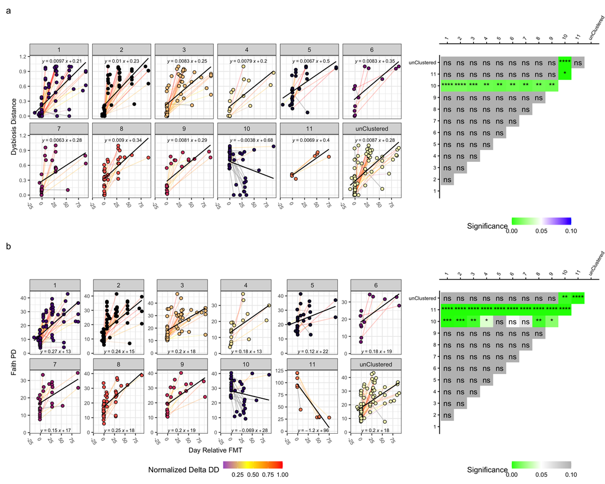

```r
FiS9
```

```r
DDFacetModel / FaithFacetModel->AltFig6

pdf("~/Desktop/Lozupone_022425/Keith/Metaanalysis/metaManuscript/UpdatedData082826/AltFig6_090926.pdf", width = 15, height = 12)
AltFig6
dev.off()
```

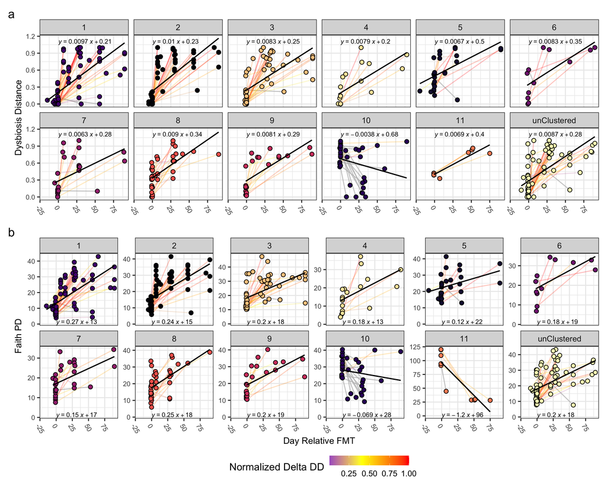

```r
AltFig6
```

```r
pdf("~/Desktop/Lozupone_022425/Keith/Metaanalysis/metaManuscript/UpdatedData082826/ClusterOtherPlots_090926.pdf", width = 11, height = 8.5)
normDistDiffPrePostMatchFMT %>%
  filter(fmt_status == "PreFMT") %>%
   ggplot(aes(x= PC4, y = NormedDelta)) +
        labs(title = "Change in Dysbiosis Distance ~ Unweighted PC4",
       subtitle = "Matched Pre- & Post-FMT",
       x = "PC4 Coordinate",
       y = "Change in Dysbiosis Distance (Pre to Post)",
       tag = "b") +
    theme_bw(base_size = 18) +
  scale_y_log10(labels = label_number())+
    geom_point(aes(fill = unNeighborClusters), pch = 21, size = 3, color = 'black') +
    geom_smooth(aes(color = unNeighborClusters),method = "lm", se = FALSE, alpha = 0.3) +
        discrete_scale(aesthetics = "fill",
               palette = function(x) c(DysbioColors),
                labels = c("1","2","3","4","5","6","7","8","9","10","11", "BTC"))+
            discrete_scale(aesthetics = "color",
               palette = function(x) c(DysbioColors))+
                guides(color = "none")+
          theme(legend.position="right",
        legend.title = element_blank(),
        plot.title = element_text( size = 14),
        plot.subtitle = element_text( size = 12),
        legend.margin = margin(t = 0, b = 0, r = 0, l = 0)) ->DeltaPC4Scatter
DeltaPC4Scatter

normDistDiffPrePostMatchFMT %>%
  filter(fmt_status == "PreFMT") %>%
   ggplot(aes(x= PC2Dys_Wt, y = deltaDistance)) +
        labs(title = "Change in Dysbiosis Distance ~ Weighted PC2",
       subtitle = "Matched Pre- & Post-FMT",
       x = "PC2 Coordinate",
       y = "Change in Dysbiosis Distance (Pre to Post)",
       tag = "b") +
    theme_bw(base_size = 18) +
    geom_point(aes(fill = unNeighborClusters), pch = 21, size = 3, color = 'black') +
    geom_smooth(aes(color = unNeighborClusters),method = "lm", se = FALSE, alpha = 0.3) +
        discrete_scale(aesthetics = "fill",
               palette = function(x) c(DysbioColors),
                labels = c("1","2","3","4","5","6","7","8","9","10","11", "BTC"))+
            discrete_scale(aesthetics = "color",
               palette = function(x) c(DysbioColors))+
          guides(color = "none")+
          theme(legend.position="right",
        legend.title = element_blank(),
        plot.title = element_text( size = 14),
        plot.subtitle = element_text( size = 12),
        legend.margin = margin(t = 0, b = 0, r = 0, l = 0))->DeltaPC2Scatter
DeltaPC2Scatter

normDistDiffPrePostMatchFMT %>%
  filter(fmt_status == "PreFMT") %>%
   ggplot(aes(x= FaithPD, y = deltaDistance)) +
        labs(title = "Change in Dysbiosis Distance ~ Faith PD",
       subtitle = "Matched Pre- & Post-FMT",
       x = "FaithPD",
       y = "Change in Dysbiosis Distance (Pre to Post)",
       tag = "b") +
    theme_bw(base_size = 18) +
    geom_point(aes(fill = unNeighborClusters), pch = 21, size = 3, color = 'black') +
    geom_smooth(aes(color = unNeighborClusters),method = "lm", se = FALSE, alpha = 0.3) +
  scale_x_log10(labels = label_number())+
        discrete_scale(aesthetics = "fill",
               palette = function(x) c(DysbioColors),
                labels = c("1","2","3","4","5","6","7","8","9","10","11", "BTC"))+
            discrete_scale(aesthetics = "color",
               palette = function(x) c(DysbioColors))+
          guides(color = "none")+
          theme(legend.position="right",
        legend.title = element_blank(),
        plot.title = element_text( size = 14),
        plot.subtitle = element_text( size = 12),
        legend.margin = margin(t = 0, b = 0, r = 0, l = 0)) ->DeltaFaithScatter
DeltaFaithScatter
dev.off()
```

Keith wants to know if rCDI varies from initial CDI in response

```r
pdf("~/Desktop/Lozupone_022425/Keith/Metaanalysis/metaManuscript/UpdatedData082826/CamachoClusterModels.pdf", width = 11, height = 8.5)
normDistDiffPrePostMatchFMT %>%
  filter(experiment_title == "Initial FMT") %>%
    group_by(study_hostID) %>%
    filter(day_relative_to_fmt2 > -89) %>%
    mutate(has_both = n_distinct(fmt_status) == 2) %>%
  filter(has_both == TRUE) %>%
  fill(unNeighborClusters, .direction = "downup") %>%
  ungroup() %>%
  ggplot(aes(x=day_relative_to_fmt2,y=dysbiosis_dist, fill = unNeighborClusters))+
    theme_bw(base_size = 18) +
      labs(
       x = NULL,
       y = "Dysbiosis Distance",
       tag = "a") +
    geom_path(data = . %>%
              filter(NormedDelta < 0),
              aes(group = study_hostID), color = "grey", alpha = 0.75)+
    geom_path(data = . %>%
                    filter(NormedDelta >= 0),
              aes(group = study_hostID, color = NormedDelta), alpha = 0.25)+
    geom_point(pch = 21, size = 3, color = 'black') +
  geom_smooth(method = "lm",se = FALSE, color = 'black', size = 1)+
          discrete_scale(aesthetics = "fill",
               palette = function(x) c(DysbioColors), guide =  "none")+
  stat_regline_equation(label.x = 0.1, label.y = 1.1, size =4)+
          scale_color_gradient2(low = "blue",
                            mid = "yellow",
                            high = "red",
                            midpoint = 0.2,
                            trans = "pseudo_log",
                            guide = guide_colorbar(barwidth= unit(5, "cm"),
                                                    title = "Normalized Delta DD"))+
  facet_wrap(~unNeighborClusters, nrow = 2)+
  theme(legend.position="none",
        axis.title.x = element_text(size = 16),
        axis.text.x = element_text(size = 12,angle = 300, hjust = 0),
        axis.title.y = element_text(size = 16),
        axis.text.y = element_text(size = 12),
        plot.title = element_text( size = 18),
        plot.subtitle = element_text( size = 16),
        legend.margin = margin(t = 0, b = 0, r = 0, l = 0))


normDistDiffPrePostMatchFMT %>%
  filter(fmt_status == "PreFMT") %>%
  ggplot(aes(y= NormedDelta, x= experiment_title))+
  geom_boxplot()+    coord_trans(y = "pseudo_log", ylim = c(-60,1.15))+
  scale_y_continuous(breaks = c(-50, -25,-10,-5,-2.5,-1,0,1))


normDistDiffPrePostMatchFMT  %>%
  ungroup() %>%
  filter(fmt_status == 'PreFMT') %>%#237 obs
  kruskal.test(data = ., NormedDelta~experiment_title)->myNormStudyKruskal
print(myNormStudyKruskal)
```

```
##
##  Kruskal-Wallis rank sum test
##
## data:  NormedDelta by experiment_title
## Kruskal-Wallis chi-squared = 65.342, df = 12, p-value = 2.357e-09
```

```r
normDistDiffPrePostMatchFMT  %>%
  ungroup() %>%
  filter(fmt_status == 'PreFMT') %>%#237 obs
  kruskal_effsize(data = ., NormedDelta~experiment_title)->myNormStudyEffect
print(myNormStudyEffect)
```

```
## # A tibble: 1 × 5
##   .y.             n effsize method  magnitude
## * <chr>       <int>   <dbl> <chr>   <ord>
## 1 NormedDelta   237   0.238 eta2[H] large
```

```r
normDistDiffPrePostMatchFMT  %>%
  ungroup() %>%
  filter(fmt_status == 'PreFMT') %>%
  dunn_test(data = ., NormedDelta ~ experiment_title, p.adjust.method = "BH")->StudyNormDunn
write_tsv(StudyNormDunn, "~/Desktop/Lozupone_022425/Keith/Metaanalysis/metaManuscript/UpdatedData082826/StudyNormDunn_090926.tsv", quote ="none")

normDistDiffPrePostMatchFMT  %>%
  filter(fmt_status == 'PreFMT') %>%
  ggplot(aes(y= NormedDelta, x= experiment_title)) +
    labs(title = "Normalized Delta Dysbiosis Scores ~ Study",
       x = "Study",
       y = "Normalized Change from Baseline (log10 scale)",
       tag = "d") +
  theme_bw(base_size = 18) +
  geom_boxplot()+
  geom_point(aes(fill =unNeighborClusters), pch = 21, size =2.5)+
  stat_compare_means(method = "kruskal.test",label.y = -30, aes(label = paste0("p = ", after_stat(p.format)))) +
        discrete_scale(aesthetics = "fill",
               palette = function(x) c(DysbioColors))+
    coord_trans(y = "pseudo_log", ylim = c(-60,1.15))+
  scale_y_continuous(breaks = c(-50, -25,-10,-5,-2.5,-1,0,1))+
  theme(legend.position="none",
        axis.title.x = element_text(size = 16),
        axis.text.x = element_text(size = 12,angle = 300, hjust = 0),
        axis.title.y = element_text(size = 16),
        axis.text.y = element_text(size = 12),
        plot.title = element_text( size = 18),
        plot.subtitle = element_text( size = 16),
        legend.margin = margin(t = 0, b = 0, r = 0, l = 0))->normStudyBoxNoBar
normStudyBoxNoBar

StudyNormDunn%>%
ggplot(aes(x = group1, y = group2)) +
      theme_classic(base_size = 18) +
  geom_tile(aes(fill = statistic), alpha = 0.8)+
  geom_tile(data = . %>%
              filter(p.adj.signif == "ns"), fill = "grey")+
  scale_x_discrete(position = "top")+
    scale_y_discrete()+
  geom_text( data = . %>%
               filter(p.adj.signif != "ns"),
             aes(label = p.adj.signif), size = 6)+
            scale_fill_gradientn(colors = c("blue", "white", "green"),
                            values = rescale(c(-10,0,10)),
                            breaks = c(-10,-5, 0, 5, 10),
                            limits = c(-10, 10),
                            oob = scales::squish,
                            guide = guide_colorbar(barwidth= unit(7, "cm"),
                                                    title = "Z-Value"))+
  theme(legend.position="bottom",
        axis.title.x = element_blank(),
        axis.text.x = element_text(size = 12,angle = 60, hjust = 0),
        axis.title.y = element_blank(),
        axis.text.y = element_text(size = 12),
        plot.title = element_text( size = 18),
        plot.subtitle = element_text( size = 16),
        legend.margin = margin(t = 0, b = 0, r = 0, l = 0))->normStudySigPlot
normStudySigPlot
((normStudyBoxNoBar) | normStudySigPlot)+
  plot_layout(ncol = 2, widths = c(2.5, 1))->studyBox
dev.off()
```

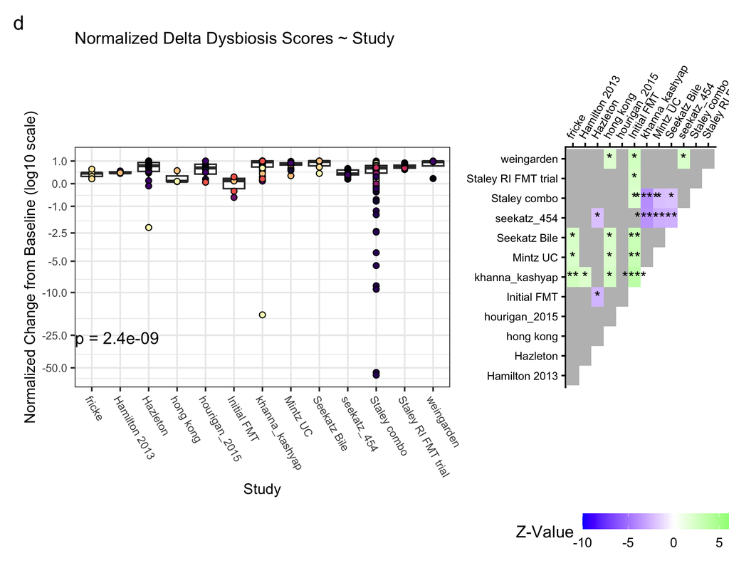

```r
studyBox
```

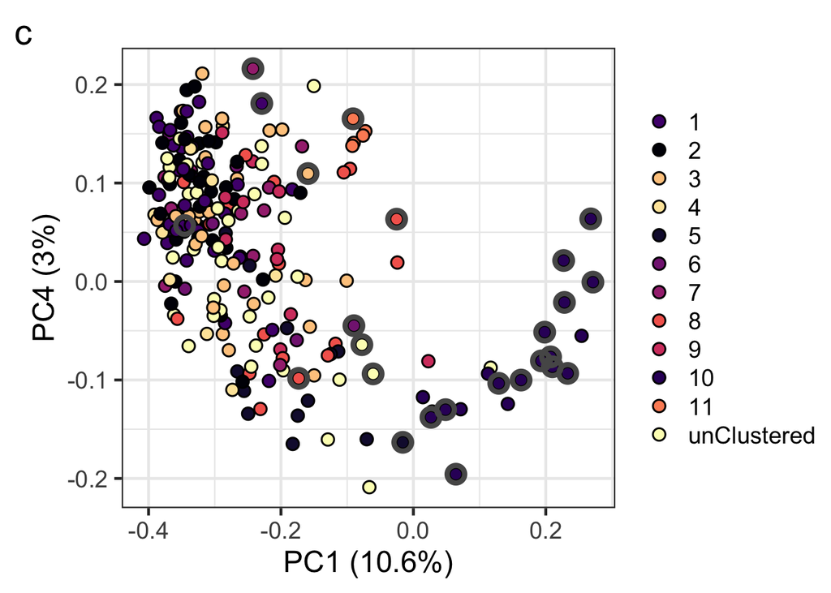

```r
normDistDiffPrePostMatchFMT %>%
  filter(fmt_status == "PreFMT") %>%
  ggplot(aes(PC1,PC4)) +
    theme_bw(base_size = 18) +
    xlab(unweighted1_xaxis) +
    ylab(unweighted4_yaxis) +
  labs(tag = "c") +
    geom_point(aes(fill = unNeighborClusters), pch = 21, size = 3, color = 'black') +
        discrete_scale(aesthetics = "fill",
               palette = function(x) c(DysbioColors),
                labels = c("1","2","3","4","5","6","7","8","9","10","11", "BTC"))+
            discrete_scale(aesthetics = "fill",
               palette = function(x) c(DysbioColors))+
      geom_point(data = . %>%
               filter(NormedDelta < 0), color = "grey34",stroke =2.25, pch = 21, size = 3.5)+
    # geom_point(data = . %>%
    #              filter(NormedDelta >= 0),
    #            aes(color = NormedDelta),stroke =2.25, pch = 21, size = 3) +
    #         scale_color_gradient2(low = "blue",
    #                         mid = "yellow",
    #                         high = "red",
    #                         midpoint = 0.2,
    #                         trans = "pseudo_log",
    #                         guide = guide_colorbar(barwidth= unit(5, "cm"),
    #                                                 title = "Normalized Delta DD"))+
                guides(color = "none")+
          theme(legend.position="right",
        legend.title = element_blank(),
        plot.title = element_text( size = 14),
        plot.subtitle = element_text( size = 12),
        legend.margin = margin(t = 0, b = 0, r = 0, l = 0))
```